# B-CNN con modelo base VGG-16 (Conjunto de datos reducido)

En primer lugar, importamos las librerías necesarias para ejecutar este cuaderno.

```python
from fastai.vision.all import *
```

Definimos la ruta que contiene las imágenes del conjunto de datos.

```python
path = Path('/root/Documents/images')
```

Listamos el directorio establecido para mostrar las carpetas por clase que contienen dicho directorio.

```python
path.ls()
```

```
(#144) [Path('/root/Documents/images/Amblyglyphidodon aureus'),Path('/root/Documents/images/Carassius auratus'),Path('/root/Documents/images/Abudefduf vaigiensis'),Path('/root/Documents/images/Cyprinella lutrensis'),Path('/root/Documents/images/Luxilus cornutus'),Path('/root/Documents/images/Chrysip…
```

Definimos la ruta padre del proyecto donde se encuentran los datos.

```python
df_path = Path('/root/Documents/')
```

Cargamos el archivo CSV en forma de *dataframe* de Pandas con las clases jerárquicas de cada imagen, la ruta de la imagen y si corresponde o no al conjunto de validación.

```python
df = pd.read_csv(df_path/"csv/families3-stratified.csv")
```

```python
df
```

|  | Order | Family | Subfamily | Genus | Specie | fname | is_valid |
| --- | --- | --- | --- | --- | --- | --- | --- |
| 0 | Perciformes | Centrarchidae | NaN | Ambloplites | Ambloplites rupestris | Ambloplites rupestris/25240275.jpg | False |
| 1 | Perciformes | Centrarchidae | NaN | Micropterus | Micropterus salmoides | Micropterus salmoides/65295609.jpg | False |
| 2 | Perciformes | Centrarchidae | NaN | Micropterus | Micropterus salmoides | Micropterus salmoides/47839127.jpg | False |
| 3 | Perciformes | Pomacentridae | Pomacentrinae | Abudefduf | Abudefduf abdominalis | Abudefduf abdominalis/14442685.jpg | False |
| 4 | Perciformes | Pomacentridae | Pomacentrinae | Chromis | Chromis multilineata | Chromis multilineata/49300790.jpg | False |
| ... | ... | ... | ... | ... | ... | ... | ... |
| 86383 | Perciformes | Pomacentridae | Pomacentrinae | Mecaenichthys | Mecaenichthys immaculatus | Mecaenichthys immaculatus/26249475.jpg | True |
| 86384 | Cypriniformes | Cyprinidae | Leuciscinae | Chrosomus | Chrosomus eos | Chrosomus eos/89045981.jpg | True |
| 86385 | Perciformes | Pomacentridae | Pomacentrinae | Pomacentrus | Pomacentrus coelestis | Pomacentrus coelestis/5496001.jpg | True |
| 86386 | Cypriniformes | Cyprinidae | Cyprininae | Cyprinus | Cyprinus carpio | Cyprinus carpio/41270267.jpg | True |
| 86387 | Perciformes | Centrarchidae | NaN | Lepomis | Lepomis cyanellus | Lepomis cyanellus/91535553.jpg | True |

86388 rows × 7 columns

Cargamos los pesos en forma de *dataframes* de las clases para corregir el desbalanceo durante el entrenamiento.

```python
weights_df = pd.read_csv(df_path/'csv/families3-weights.csv')
weights_family_df = pd.read_csv(df_path/'csv/families3-weights-family.csv')
weights_order_df = pd.read_csv(df_path/'csv/families3-weights-order.csv')
weights_genus_df = pd.read_csv(df_path/'csv/families3-weights-genus.csv')
```

Mostramos, como ejemplo, el *dataframe* de los pesos por clase final.

```python
weights_df
```

|  | Specie | Count | Weight |
| --- | --- | --- | --- |
| 0 | Abramis brama | 300 | 1.999722 |
| 1 | Abudefduf abdominalis | 177 | 3.389360 |
| 2 | Abudefduf bengalensis | 299 | 2.006410 |
| 3 | Abudefduf saxatilis | 1423 | 0.421586 |
| 4 | Abudefduf septemfasciatus | 128 | 4.686849 |
| ... | ... | ... | ... |
| 139 | Stegastes partitus | 174 | 3.447797 |
| 140 | Stegastes planifrons | 178 | 3.370318 |
| 141 | Systomus rubripinnis | 587 | 1.022005 |
| 142 | Telestes muticellus | 144 | 4.166088 |
| 143 | Tinca tinca | 246 | 2.438686 |

144 rows × 3 columns

## Experimento 1: Sin ramas

Creamos un *datablock* con: bloques de tipo imagen y categoría, un separador por columna, la *x* con la columna que contienen la ruta de las imágenes, la *y* con la columna de especies, una transformación para hacer un recorte aleatorio dejando un tamaño común de 336x336, y las transformaciones de aumento de datos por defecto.

```python
fishes = DataBlock(blocks = (ImageBlock, CategoryBlock),
                 splitter=ColSplitter(),
                 get_x = ColReader(5, pref=path),
                 get_y=ColReader(4),
                 item_tfms=RandomResizedCrop(336, min_scale=0.5),
                 batch_tfms=aug_transforms())
dls = fishes.dataloaders(df, bs=64)
```

Mostramos los *dataloaders* generados con el *datablock*.

```python
dls.train_ds, dls.valid_ds
```

```
((#69110) [(PILImage mode=RGB size=1024x768, TensorCategory(13)),(PILImage mode=RGB size=1024x768, TensorCategory(83)),(PILImage mode=RGB size=768x1024, TensorCategory(83)),(PILImage mode=RGB size=1024x915, TensorCategory(1)),(PILImage mode=RGB size=1024x768, TensorCategory(38)),(PILImage mode=RGB s…
 (#17278) [(PILImage mode=RGB size=768x1024, TensorCategory(83)),(PILImage mode=RGB size=1024x636, TensorCategory(83)),(PILImage mode=RGB size=1024x768, TensorCategory(52)),(PILImage mode=RGB size=1024x768, TensorCategory(42)),(PILImage mode=RGB size=768x1024, TensorCategory(69)),(PILImage mode=RGB …
```

Mostramos algunos ejemplos de los *dataloaders*.

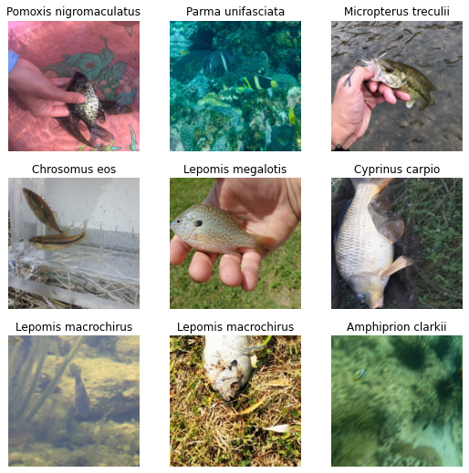

```python
dls.show_batch(nrows=3, ncols=3)
```

Creamos una clase para nuestro modelo que enlace un *encoder* y *head*.

```python
class VGGCustomModel(Module):
    def __init__(self, encoder, head):
        self.encoder = encoder
        self.head = head

    def forward(self, x):
        x = self.encoder(x)
        x = self.head(x)
        return x
```

Creamos un *splitter* personalizado con los parámetros del *encoder* y del *head*.

```python
def custom_splitter(model):
    return [params(model.encoder),
            params(model.head)]
```

Creamos el cuerpo (*encoder*) y cabeza del modelo tomando como base VGG-16 con *Batch Normalization* y con pesos preentrenados.

```python
model = vgg16_bn
body = create_body(model, cut=-2)
head = create_head(512*2,dls.c)
```

```
Downloading: "https://download.pytorch.org/models/vgg16_bn-6c64b313.pth" to /root/.cache/torch/hub/checkpoints/vgg16_bn-6c64b313.pth
```

Creamos el modelo con la clase previamente creada, suministrando el cuerpo y la cabeza del modelo.

```python
model = VGGCustomModel(body, head)
```

Creamos el tensor con los pesos por clase y lo pasamos a GPU para poder usarlo durante el entrenamiento.

```python
weights = tensor([float(weights_df[weights_df['Specie']==c]['Weight']) for c in dls.vocab]).cuda()
```

Creamos nuestro objeto *Learner* con los *dataloaders*, la función de pérdida de entropía cruzada con los pesos calculados, la métrica exactitud y el *splitter* creado. Además, congelamos nuestro modelo para ajustar primero los pesos preentrenados a nuestras clases.

```python
learn = Learner(dls, model, loss_func=nn.CrossEntropyLoss(weight=weights), metrics=accuracy,
                   splitter=custom_splitter).to_fp16()
learn.freeze()
```

Mostramos un resumen de nuestro modelo.

```python
learn.summary()
```

| epoch | train_loss | valid_loss | accuracy | time |
| --- | --- | --- | --- | --- |
| 0 | None | None | 00:00 |  |

```
VGGCustomModel (Input shape: ['64 x 3 x 336 x 336'])
================================================================
Layer (type)         Output Shape         Param #    Trainable
================================================================
Conv2d               64 x 64 x 336 x 336  1,792      False
________________________________________________________________
BatchNorm2d          64 x 64 x 336 x 336  128        True
________________________________________________________________
ReLU                 64 x 64 x 336 x 336  0          False
________________________________________________________________
Conv2d               64 x 64 x 336 x 336  36,928     False
________________________________________________________________
BatchNorm2d          64 x 64 x 336 x 336  128        True
________________________________________________________________
ReLU                 64 x 64 x 336 x 336  0          False
________________________________________________________________
MaxPool2d            64 x 64 x 168 x 168  0          False
________________________________________________________________
Conv2d               64 x 128 x 168 x 16  73,856     False
________________________________________________________________
BatchNorm2d          64 x 128 x 168 x 16  256        True
________________________________________________________________
ReLU                 64 x 128 x 168 x 16  0          False
________________________________________________________________
Conv2d               64 x 128 x 168 x 16  147,584    False
________________________________________________________________
BatchNorm2d          64 x 128 x 168 x 16  256        True
________________________________________________________________
ReLU                 64 x 128 x 168 x 16  0          False
________________________________________________________________
MaxPool2d            64 x 128 x 84 x 84   0          False
________________________________________________________________
Conv2d               64 x 256 x 84 x 84   295,168    False
________________________________________________________________
BatchNorm2d          64 x 256 x 84 x 84   512        True
________________________________________________________________
ReLU                 64 x 256 x 84 x 84   0          False
________________________________________________________________
Conv2d               64 x 256 x 84 x 84   590,080    False
________________________________________________________________
```

[output cut: 73 more lines]

```
Total params: 15,324,224
Total trainable params: 609,536
Total non-trainable params: 14,714,688

Optimizer used: <function Adam at 0x7f5a5c481160>
Loss function: CrossEntropyLoss()

Model frozen up to parameter group #1

Callbacks:
  - ModelToHalf
  - TrainEvalCallback
  - Recorder
  - ProgressCallback
  - MixedPrecision
```

Entrenamos el modelo congelado para ajustar los pesos de las últimas capas a nuestras clases, y descongelamos el modelo.

```python
learn.fit(1, 3e-3)
learn.unfreeze()
```

| epoch | train_loss | valid_loss | accuracy | time |
| --- | --- | --- | --- | --- |
| 0 | 2.896088 | 2.335769 | 0.363005 | 08:27 |

Buscamos el factor de aprendizaje más adecuado con lr_find.

```python
learn.lr_find()
```

[output not shown]

Entrenamos durante 10 épocas con el factor de aprendizaje máximo adecuado según la visualización del buscador de factores de aprendizaje.

```python
learn.fit(10, slice(1e-6,1e-4))
learn.save('families3-vgg16-exp1-fepochs1-uepochs10')
```

| epoch | train_loss | valid_loss | accuracy | time |
| --- | --- | --- | --- | --- |
| 0 | 2.303873 | 1.987007 | 0.419840 | 09:55 |
| 1 | 2.140742 | 1.888510 | 0.442702 | 09:57 |
| 2 | 2.085618 | 1.824269 | 0.464290 | 09:55 |
| 3 | 2.029214 | 1.765150 | 0.470309 | 09:54 |
| 4 | 1.902038 | 1.711232 | 0.485936 | 09:54 |
| 5 | 1.889917 | 1.675820 | 0.493749 | 09:54 |
| 6 | 1.785733 | 1.641474 | 0.500521 | 09:54 |
| 7 | 1.758970 | 1.610050 | 0.508450 | 09:54 |
| 8 | 1.719398 | 1.580571 | 0.506772 | 09:53 |
| 9 | 1.682009 | 1.546445 | 0.517247 | 09:53 |

```
Path('models/families3-vgg16-exp1-fepochs1-uepochs10.pth')
```

Defimos una función para continuar el aprendizaje con los pesos guardados.

```python
def continue_training(pth_filename):
    learn = Learner(dls, model, loss_func=nn.CrossEntropyLoss(weight=weights), metrics=accuracy,
                       splitter=custom_splitter).to_fp16()
    learn.load(pth_filename)
    learn.unfreeze()
    return learn
```

```python
learn = continue_training('families3-vgg16-exp1-fepochs1-uepochs10')
```

Continuamos entrenando nuestro modelo hasta las 50 épocas, guardando los pesos del entrenamiento en cada 10 épocas.

```python
learn.fit(10, slice(1e-6,1e-4))
learn.save('families3-vgg16-exp1-fepochs1-uepochs20')
```

| epoch | train_loss | valid_loss | accuracy | time |
| --- | --- | --- | --- | --- |
| 0 | 1.661437 | 1.531346 | 0.526508 | 10:01 |
| 1 | 1.593528 | 1.507088 | 0.532469 | 09:56 |
| 2 | 1.560788 | 1.483030 | 0.536926 | 09:56 |
| 3 | 1.549441 | 1.457012 | 0.536636 | 09:56 |
| 4 | 1.543200 | 1.444104 | 0.543524 | 09:55 |
| 5 | 1.476572 | 1.425767 | 0.546128 | 09:56 |
| 6 | 1.446751 | 1.410694 | 0.545954 | 09:55 |
| 7 | 1.396688 | 1.395607 | 0.557125 | 09:55 |
| 8 | 1.344562 | 1.377572 | 0.563318 | 09:56 |
| 9 | 1.439484 | 1.367067 | 0.570379 | 09:56 |

```
Path('models/families3-vgg16-exp1-fepochs1-uepochs20.pth')
```

```python
learn = continue_training('families3-vgg16-exp1-fepochs1-uepochs20')
```

```python
learn.fit(10, slice(1e-6,1e-4))
learn.save('families3-vgg16-exp1-fepochs1-uepochs30')
```

| epoch | train_loss | valid_loss | accuracy | time |
| --- | --- | --- | --- | --- |
| 0 | 1.337438 | 1.347025 | 0.568237 | 09:52 |
| 1 | 1.330133 | 1.342888 | 0.572115 | 09:48 |
| 2 | 1.357262 | 1.328623 | 0.578366 | 09:48 |
| 3 | 1.289343 | 1.318600 | 0.587047 | 09:47 |
| 4 | 1.287316 | 1.315599 | 0.583748 | 09:48 |
| 5 | 1.278316 | 1.305957 | 0.585484 | 09:47 |
| 6 | 1.245854 | 1.283947 | 0.588378 | 09:48 |
| 7 | 1.210050 | 1.275306 | 0.590346 | 09:48 |
| 8 | 1.197506 | 1.265643 | 0.593008 | 09:48 |
| 9 | 1.227446 | 1.262720 | 0.598159 | 09:48 |

```
Path('models/families3-vgg16-exp1-fepochs1-uepochs30.pth')
```

```python
learn = continue_training('families3-vgg16-exp1-fepochs1-uepochs30')
```

```python
learn.fit(10, slice(1e-6,1e-4))
learn.save('families3-vgg16-exp1-fepochs1-uepochs40')
```

| epoch | train_loss | valid_loss | accuracy | time |
| --- | --- | --- | --- | --- |
| 0 | 1.253275 | 1.248294 | 0.596539 | 10:01 |
| 1 | 1.192674 | 1.246150 | 0.599259 | 09:57 |
| 2 | 1.208163 | 1.229039 | 0.599780 | 09:57 |
| 3 | 1.137049 | 1.228606 | 0.606667 | 09:59 |
| 4 | 1.138947 | 1.223850 | 0.609272 | 09:58 |
| 5 | 1.122190 | 1.218193 | 0.617953 | 09:59 |
| 6 | 1.125025 | 1.209456 | 0.615233 | 09:59 |
| 7 | 1.107584 | 1.200260 | 0.618301 | 10:00 |
| 8 | 1.106618 | 1.197138 | 0.627850 | 10:00 |
| 9 | 1.102644 | 1.195521 | 0.616275 | 09:58 |

```
Path('models/families3-vgg16-exp1-fepochs1-uepochs40.pth')
```

```python
learn = continue_training('families3-vgg16-exp1-fepochs1-uepochs40')
```

```python
learn.fit(10, slice(1e-6,1e-4))
learn.save('families3-vgg16-exp1-fepochs1-uepochs50')
```

| epoch | train_loss | valid_loss | accuracy | time |
| --- | --- | --- | --- | --- |
| 0 | 1.079943 | 1.184888 | 0.619921 | 10:02 |
| 1 | 1.064073 | 1.187792 | 0.618822 | 09:56 |
| 2 | 1.044685 | 1.173324 | 0.625477 | 09:57 |
| 3 | 0.992804 | 1.170871 | 0.627503 | 09:57 |
| 4 | 1.018720 | 1.164860 | 0.629297 | 09:57 |
| 5 | 0.988018 | 1.160671 | 0.632249 | 09:57 |
| 6 | 1.017702 | 1.158159 | 0.635201 | 09:57 |
| 7 | 1.009106 | 1.150154 | 0.641915 | 09:57 |
| 8 | 0.916355 | 1.154384 | 0.642493 | 09:56 |
| 9 | 0.949946 | 1.145804 | 0.636706 | 09:56 |

```
Path('models/families3-vgg16-exp1-fepochs1-uepochs50.pth')
```

```python
learn.export('families3-vgg16-exp1-fepochs1-uepochs50')
```

## Experimento 2: 1 Rama (orden)

Creamos el cuerpo (*encoder*) y cabeza del modelo tomando como base VGG-16 con *Batch Normalization* y con pesos preentrenados.

```python
model = vgg16_bn
body = create_body(model, cut=-2)
body
```

```
Downloading: "https://download.pytorch.org/models/vgg16_bn-6c64b313.pth" to /root/.cache/torch/hub/checkpoints/vgg16_bn-6c64b313.pth
```

```
Sequential(
  (0): Sequential(
    (0): Conv2d(3, 64, kernel_size=(3, 3), stride=(1, 1), padding=(1, 1))
    (1): BatchNorm2d(64, eps=1e-05, momentum=0.1, affine=True, track_running_stats=True)
    (2): ReLU(inplace=True)
    (3): Conv2d(64, 64, kernel_size=(3, 3), stride=(1, 1), padding=(1, 1))
    (4): BatchNorm2d(64, eps=1e-05, momentum=0.1, affine=True, track_running_stats=True)
    (5): ReLU(inplace=True)
    (6): MaxPool2d(kernel_size=2, stride=2, padding=0, dilation=1, ceil_mode=False)
    (7): Conv2d(64, 128, kernel_size=(3, 3), stride=(1, 1), padding=(1, 1))
    (8): BatchNorm2d(128, eps=1e-05, momentum=0.1, affine=True, track_running_stats=True)
    (9): ReLU(inplace=True)
    (10): Conv2d(128, 128, kernel_size=(3, 3), stride=(1, 1), padding=(1, 1))
    (11): BatchNorm2d(128, eps=1e-05, momentum=0.1, affine=True, track_running_stats=True)
    (12): ReLU(inplace=True)
    (13): MaxPool2d(kernel_size=2, stride=2, padding=0, dilation=1, ceil_mode=False)
    (14): Conv2d(128, 256, kernel_size=(3, 3), stride=(1, 1), padding=(1, 1))
    (15): BatchNorm2d(256, eps=1e-05, momentum=0.1, affine=True, track_running_stats=True)
    (16): ReLU(inplace=True)
    (17): Conv2d(256, 256, kernel_size=(3, 3), stride=(1, 1), padding=(1, 1))
    (18): BatchNorm2d(256, eps=1e-05, momentum=0.1, affine=True, track_running_stats=True)
    (19): ReLU(inplace=True)
    (20): Conv2d(256, 256, kernel_size=(3, 3), stride=(1, 1), padding=(1, 1))
    (21): BatchNorm2d(256, eps=1e-05, momentum=0.1, affine=True, track_running_stats=True)
    (22): ReLU(inplace=True)
    (23): MaxPool2d(kernel_size=2, stride=2, padding=0, dilation=1, ceil_mode=False)
    (24): Conv2d(256, 512, kernel_size=(3, 3), stride=(1, 1), padding=(1, 1))
    (25): BatchNorm2d(512, eps=1e-05, momentum=0.1, affine=True, track_running_stats=True)
    (26): ReLU(inplace=True)
    (27): Conv2d(512, 512, kernel_size=(3, 3), stride=(1, 1), padding=(1, 1))
    (28): BatchNorm2d(512, eps=1e-05, momentum=0.1, affine=True, track_running_stats=True)
    (29): ReLU(inplace=True)
    (30): Conv2d(512, 512, kernel_size=(3, 3), stride=(1, 1), padding=(1, 1))
    (31): BatchNorm2d(512, eps=1e-05, momentum=0.1, affine=True, track_running_stats=True)
    (32): ReLU(inplace=True)
    (33): MaxPool2d(kernel_size=2, stride=2, padding=0, dilation=1, ceil_mode=False)
    (34): Conv2d(512, 512, kernel_size=(3, 3), stride=(1, 1), padding=(1, 1))
    (35): BatchNorm2d(512, eps=1e-05, momentum=0.1, affine=True, track_running_stats=True)
    (36): ReLU(inplace=True)
    (37): Conv2d(512, 512, kernel_size=(3, 3), stride=(1, 1), padding=(1, 1))
    (38): BatchNorm2d(512, eps=1e-05, momentum=0.1, affine=True, track_running_stats=True)
    (39): ReLU(inplace=True)
    (40): Conv2d(512, 512, kernel_size=(3, 3), stride=(1, 1), padding=(1, 1))
    (41): BatchNorm2d(512, eps=1e-05, momentum=0.1, affine=True, track_running_stats=True)
    (42): ReLU(inplace=True)
    (43): MaxPool2d(kernel_size=2, stride=2, padding=0, dilation=1, ceil_mode=False)
  )
)
```

```python
head = create_head(512*2,dls.c)
head
```

```
Sequential(
  (0): AdaptiveConcatPool2d(
    (ap): AdaptiveAvgPool2d(output_size=1)
    (mp): AdaptiveMaxPool2d(output_size=1)
  )
  (1): Flatten(full=False)
  (2): BatchNorm1d(1024, eps=1e-05, momentum=0.1, affine=True, track_running_stats=True)
  (3): Dropout(p=0.25, inplace=False)
  (4): Linear(in_features=1024, out_features=512, bias=False)
  (5): ReLU(inplace=True)
  (6): BatchNorm1d(512, eps=1e-05, momentum=0.1, affine=True, track_running_stats=True)
  (7): Dropout(p=0.5, inplace=False)
  (8): Linear(in_features=512, out_features=144, bias=False)
)
```

Separamos el cuerpo de la arquitectura en los distintos bloques para definir cada uno de ellos y aplicar posteriormente una rama entre el bloque 1 y el bloque 2.

```python
_body = body[0]
block1 = _body[:7]
block2 = _body[7:14]
block3 = _body[14:24]
block4 = _body[24:34]
block5 = _body[34:]
```

Definimos una función para obtener las etiquetas de cada ejemplo, en este caso: el orden y la especie.

```python
def custom_get_y(o):
    fine_label = o['Specie']
    coarse1_label = o['Order']
    return [coarse1_label, fine_label]
```

Creamos una clase para nuestro modelo que divida el *encoder* en los distintos bloques y añada una cabeza entre el bloque 1 y 2 como rama con el número de clases de *Order*. En el método *forward* establecemos la conexión de los distintos bloques, separando la salida de la rama del flujo normal, para así devolver ambas salidas en forma de diccionario.

```python
class VGGCustomModel(Module):
    def __init__(self, encoder, head):
        self.encoder = encoder
        encoder = encoder[0]
        self.block1 = encoder[:7]
        self.branch1 = create_head(64*2, len(set(df['Order'])))
        self.block2 = encoder[7:14]
        self.block3 = encoder[14:24]
        self.block4 = encoder[24:34]
        self.block5 = encoder[34:]
        self.head = head

    def forward(self, x):
        x = self.block1(x)
        coarse1_label = self.branch1(x)
        x = self.block2(x)
        x = self.block3(x)
        x = self.block4(x)
        x = self.block5(x)
        fine_label = self.head(x)
        return {
                'fine_label': fine_label,
                'coarse1_label': coarse1_label
               }
```

Creamos el modelo con la clase definida pasándole el cuerpo y cabeza.

```python
model = VGGCustomModel(body, head)
```

Como hemos modificado el modelo y la obtención de las clases para usar una salida múltiple, tenemos que modificar el tipo de bloque de categoría a uno que soporte estas salidas. Para ello, definimos una función que obtenga la clase y codifique a categoría cada una.

```python
class CustomCategorize(DisplayedTransform):
    "Reversible transform of category string to `vocab` id"
    loss_func,order=CrossEntropyLossFlat(),1
    def __init__(self, vocab=None, vocab_coarse1=None, vocab_coarse2=None, sort=True, add_na=False, num_y=1):
        store_attr()
        self.vocab = None if vocab is None else CategoryMap(vocab, sort=sort, add_na=add_na)
        self.vocab_coarse1 = None if vocab_coarse1 is None else CategoryMap(vocab_coarse1, sort=sort, add_na=add_na)

    def setups(self, dsets):
        fine_dsets = [d[1] for d in dsets]
        coarse1_dsets = [d[0] for d in dsets]
        if self.vocab is None and dsets is not None: self.vocab = CategoryMap(fine_dsets, sort=self.sort, add_na=self.add_na)
        if self.vocab_coarse1 is None and dsets is not None: self.vocab_coarse1 = CategoryMap(coarse1_dsets, sort=self.sort, add_na=self.add_na)
        self.c = len(self.vocab)

    def encodes(self, o): return {'fine_label': TensorCategory(self.vocab.o2i[o[1]]),
                                  'coarse1_label': TensorCategory(self.vocab_coarse1.o2i[o[0]])
                                 }
    def decodes(self, o): return Category      (self.vocab    [o])
```

```python
def CustomCategoryBlock(vocab=None, sort=True, add_na=False, num_y=1):
    "`TransformBlock` for single-label categorical targets"
    return TransformBlock(type_tfms=CustomCategorize(vocab=vocab, sort=sort, add_na=add_na))
```

Creamos un *splitter* personalizado con los parámetros de cada bloque y del *head*.

```python
def custom_splitter(model):
    return [params(model.block1),
            params(model.block2),
            params(model.block3),
            params(model.block4),
            params(model.block5),
            params(model.head)]
```

Creamos un *datablock* con: bloques de tipo imagen y categoría personalizada *CustomCategoryBlock*, un separador por columna, la *x* con la columna que contienen la ruta de las imágenes, la *y* con la función personalizada, una transformación para hacer un recorte aleatorio dejando un tamaño común de 336x336, y las transformaciones de aumento de datos por defecto.

```python
fishes = DataBlock(blocks = (ImageBlock, CustomCategoryBlock),
                 splitter=ColSplitter(),
                 get_x = ColReader(5, pref=path),
                 get_y=custom_get_y,
                 item_tfms=RandomResizedCrop(336, min_scale=0.5),
                 batch_tfms=aug_transforms())
dls = fishes.dataloaders(df)
```

Mostramos los *dataloaders* generados con el *datablock*.

```python
dls.train_ds, dls.valid_ds
```

```
((#69110) [(PILImage mode=RGB size=1024x768, {'fine_label': TensorCategory(13), 'coarse1_label': TensorCategory(1)}),(PILImage mode=RGB size=1024x768, {'fine_label': TensorCategory(83), 'coarse1_label': TensorCategory(1)}),(PILImage mode=RGB size=768x1024, {'fine_label': TensorCategory(83), 'coarse1…
 (#17278) [(PILImage mode=RGB size=768x1024, {'fine_label': TensorCategory(83), 'coarse1_label': TensorCategory(1)}),(PILImage mode=RGB size=1024x636, {'fine_label': TensorCategory(83), 'coarse1_label': TensorCategory(1)}),(PILImage mode=RGB size=1024x768, {'fine_label': TensorCategory(52), 'coarse1…
```

Mostramos las clases finas y las categóricas de nuestros dataloaders.

```python
dls.vocab, dls.vocab_coarse1
```

```
(['Abramis brama', 'Abudefduf abdominalis', 'Abudefduf bengalensis', 'Abudefduf saxatilis', 'Abudefduf septemfasciatus', 'Abudefduf sexfasciatus', 'Abudefduf sordidus', 'Abudefduf troschelii', 'Abudefduf vaigiensis', 'Acanthochromis polyacanthus', 'Acrossocheilus paradoxus', 'Alburnus alburnus', 'Al…
 ['Cypriniformes', 'Perciformes'])
```

Creamos el tensor con los pesos por clase y lo pasamos a GPU para poder usarlo durante el entrenamiento.

```python
weights = tensor([float(weights_df[weights_df['Specie']==c]['Weight']) for c in dls.vocab]).cuda()
weights_order = tensor([float(weights_order_df[weights_order_df['Order']==c]['Weight']) for c in dls.vocab_coarse1]).cuda()
```

Defimos nuestra función de pérdida como el sumatorio de la pérdida en entropía cruzada de las dos salidas.

```python
def loss_func(out, targ):
    return nn.CrossEntropyLoss(weight=weights)(out['fine_label'], targ['fine_label']) + \
            nn.CrossEntropyLoss(weight=weights_order)(out['coarse1_label'], targ['coarse1_label'])
```

Defimos la función de accuracy con la etiqueta fina, ya que es el resultado final que nos interesa. Además, esta etiqueta fue la que se usó para definir las particiones estratificadas, por lo que es la única que se debería tener en cuenta si queremos resultados más fiables.

```python
def custom_accuracy(inp, targ, axis=-1):
    pred1,targ1 = flatten_check(inp['fine_label'].argmax(dim=axis), targ['fine_label'])
    acc1 = (pred1 == targ1).float().mean()
    return acc1
```

Creamos nuestro objeto *Learner* con los *dataloaders*, la función de pérdida _loss*func* creada, la métrica exactitud y el *splitter* creado. Además, congelamos nuestro modelo para ajustar primero los pesos preentrenados a nuestras clases.

```python
learn = Learner(dls, model, loss_func=loss_func, metrics=custom_accuracy,
                   splitter=custom_splitter).to_fp16()
learn.freeze()
```

Mostramos un resumen de nuestro modelo.

```python
learn.summary()
```

| epoch | train_loss | valid_loss | custom_accuracy | time |
| --- | --- | --- | --- | --- |
| 0 | None | None | 00:00 |  |

```
VGGCustomModel (Input shape: ['64 x 3 x 336 x 336'])
================================================================
Layer (type)         Output Shape         Param #    Trainable
================================================================
Conv2d               64 x 64 x 336 x 336  1,792      False
________________________________________________________________
BatchNorm2d          64 x 64 x 336 x 336  128        True
________________________________________________________________
ReLU                 64 x 64 x 336 x 336  0          False
________________________________________________________________
Conv2d               64 x 64 x 336 x 336  36,928     False
________________________________________________________________
BatchNorm2d          64 x 64 x 336 x 336  128        True
________________________________________________________________
ReLU                 64 x 64 x 336 x 336  0          False
________________________________________________________________
MaxPool2d            64 x 64 x 168 x 168  0          False
________________________________________________________________
Conv2d               64 x 128 x 168 x 16  73,856     False
________________________________________________________________
BatchNorm2d          64 x 128 x 168 x 16  256        True
________________________________________________________________
ReLU                 64 x 128 x 168 x 16  0          False
________________________________________________________________
Conv2d               64 x 128 x 168 x 16  147,584    False
________________________________________________________________
BatchNorm2d          64 x 128 x 168 x 16  256        True
________________________________________________________________
ReLU                 64 x 128 x 168 x 16  0          False
________________________________________________________________
MaxPool2d            64 x 128 x 84 x 84   0          False
________________________________________________________________
Conv2d               64 x 256 x 84 x 84   295,168    False
________________________________________________________________
BatchNorm2d          64 x 256 x 84 x 84   512        True
________________________________________________________________
ReLU                 64 x 256 x 84 x 84   0          False
________________________________________________________________
Conv2d               64 x 256 x 84 x 84   590,080    False
________________________________________________________________
```

[output cut: 181 more lines]

```
Total params: 30,115,200
Total trainable params: 685,824
Total non-trainable params: 29,429,376

Optimizer used: <function Adam at 0x7f80dfffd160>
Loss function: <function loss_func at 0x7f80deccaaf0>

Model frozen up to parameter group #5

Callbacks:
  - ModelToHalf
  - TrainEvalCallback
  - Recorder
  - ProgressCallback
  - MixedPrecision
```

Entrenamos el modelo congelado para ajustar los pesos de las últimas capas a nuestras clases, y descongelamos el modelo.

```python
learn.fit(1, 3e-3)
```

| epoch | train_loss | valid_loss | custom_accuracy | time |
| --- | --- | --- | --- | --- |
| 0 | 3.618339 | 3.046000 | 0.348999 | 08:31 |

```python
learn.unfreeze()
```

Buscamos el factor de aprendizaje más adecuado con lr_find.

```
SuggestedLRs(lr_min=3.311311274956097e-07, lr_steep=8.31763736641733e-06)
```

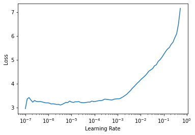

```python
learn.lr_find()
```

Entrenamos durante 10 épocas con el factor de aprendizaje máximo adecuado según la visualización del buscador de factores de aprendizaje.

```python
learn.fit(10, slice(1e-6,1e-4))
learn.save('families3-vgg16-exp2-fepochs1-uepochs10')
```

| epoch | train_loss | valid_loss | custom_accuracy | time |
| --- | --- | --- | --- | --- |
| 0 | 2.861439 | 2.403509 | 0.472624 | 09:56 |
| 1 | 2.464396 | 2.198353 | 0.526971 | 09:56 |
| 2 | 2.289629 | 2.071875 | 0.550816 | 09:57 |
| 3 | 2.192742 | 1.969096 | 0.577150 | 09:58 |
| 4 | 2.055829 | 1.910562 | 0.579812 | 09:57 |
| 5 | 1.949579 | 1.859098 | 0.613671 | 09:57 |
| 6 | 1.860937 | 1.836668 | 0.611645 | 09:57 |
| 7 | 1.741600 | 1.789288 | 0.632654 | 09:57 |
| 8 | 1.673563 | 1.752496 | 0.647008 | 09:57 |
| 9 | 1.622823 | 1.727495 | 0.653316 | 09:57 |

```
Path('models/families3-vgg16-exp2-fepochs1-uepochs10.pth')
```

Defimos una función para continuar el aprendizaje con los pesos guardados.

```python
def continue_training(pth_filename):
    learn = Learner(dls, model, loss_func=loss_func, metrics=custom_accuracy,
                   splitter=custom_splitter).to_fp16()
    learn.load(pth_filename)
    learn.unfreeze()
    return learn
```

```python
learn = continue_training('families3-vgg16-exp2-fepochs1-uepochs10')
```

Continuamos entrenando nuestro modelo hasta las 50 épocas, guardando los pesos del entrenamiento en cada 10 épocas.

```python
learn.fit(10, slice(1e-6,1e-4))
learn.save('families3-vgg16-exp2-fepochs1-uepochs20')
```

| epoch | train_loss | valid_loss | custom_accuracy | time |
| --- | --- | --- | --- | --- |
| 0 | 1.587695 | 1.721391 | 0.655516 | 10:25 |
| 1 | 1.508061 | 1.681540 | 0.669001 | 10:21 |
| 2 | 1.462826 | 1.705976 | 0.679187 | 10:20 |
| 3 | 1.448030 | 1.666520 | 0.675252 | 10:21 |
| 4 | 1.410046 | 1.659874 | 0.687290 | 10:21 |
| 5 | 1.335785 | 1.664224 | 0.688621 | 10:21 |
| 6 | 1.326378 | 1.666960 | 0.686885 | 10:22 |
| 7 | 1.289366 | 1.659517 | 0.698518 | 10:21 |
| 8 | 1.260610 | 1.669366 | 0.696551 | 10:22 |
| 9 | 1.223115 | 1.661529 | 0.711830 | 10:22 |

```
Path('models/families3-vgg16-exp2-fepochs1-uepochs20.pth')
```

```python
learn = continue_training('families3-vgg16-exp2-fepochs1-uepochs20')
```

```python
learn.fit(10, slice(1e-6,1e-4))
learn.save('families3-vgg16-exp2-fepochs1-uepochs30')
```

| epoch | train_loss | valid_loss | custom_accuracy | time |
| --- | --- | --- | --- | --- |
| 0 | 1.223095 | 1.669219 | 0.708242 | 10:21 |
| 1 | 1.166241 | 1.661148 | 0.721959 | 10:16 |
| 2 | 1.161406 | 1.637070 | 0.720975 | 10:17 |
| 3 | 1.134544 | 1.658828 | 0.716923 | 10:15 |
| 4 | 1.129207 | 1.679625 | 0.720164 | 10:16 |
| 5 | 1.118274 | 1.667176 | 0.730061 | 10:17 |
| 6 | 1.092955 | 1.683459 | 0.736659 | 10:17 |
| 7 | 1.063250 | 1.689470 | 0.728904 | 10:19 |
| 8 | 1.091430 | 1.701657 | 0.735155 | 10:20 |
| 9 | 1.034296 | 1.680427 | 0.750376 | 10:19 |

```
Path('models/families3-vgg16-exp2-fepochs1-uepochs30.pth')
```

```python
learn = continue_training('families3-vgg16-exp2-fepochs1-uepochs30')
```

```python
learn.fit(10, slice(1e-6,1e-4))
learn.save('families3-vgg16-exp2-fepochs1-uepochs40')
```

| epoch | train_loss | valid_loss | custom_accuracy | time |
| --- | --- | --- | --- | --- |
| 0 | 1.073140 | 1.700693 | 0.746441 | 10:13 |
| 1 | 1.020578 | 1.688521 | 0.747772 | 10:08 |
| 2 | 1.012898 | 1.698025 | 0.746441 | 10:08 |
| 3 | 1.041003 | 1.717521 | 0.741521 | 10:09 |
| 4 | 1.016075 | 1.716825 | 0.744183 | 10:07 |
| 5 | 0.999781 | 1.724091 | 0.753212 | 10:10 |
| 6 | 0.998665 | 1.728085 | 0.752691 | 10:10 |
| 7 | 0.984843 | 1.741851 | 0.750666 | 10:08 |
| 8 | 0.956981 | 1.707194 | 0.757090 | 10:08 |
| 9 | 0.969191 | 1.740584 | 0.755064 | 10:08 |

```
Path('models/families3-vgg16-exp2-fepochs1-uepochs40.pth')
```

```python
learn = continue_training('families3-vgg16-exp2-fepochs1-uepochs40')
```

```python
learn.fit(10, slice(1e-6,1e-4))
learn.save('families3-vgg16-exp2-fepochs1-uepochs50')
```

| epoch | train_loss | valid_loss | custom_accuracy | time |
| --- | --- | --- | --- | --- |
| 0 | 0.957517 | 1.761982 | 0.767218 | 10:01 |
| 1 | 0.936139 | 1.755194 | 0.758768 | 09:58 |
| 2 | 0.953285 | 1.715719 | 0.761315 | 09:58 |
| 3 | 0.919787 | 1.789150 | 0.767624 | 09:58 |
| 4 | 0.941290 | 1.744545 | 0.766408 | 09:59 |
| 5 | 0.918798 | 1.757224 | 0.766177 | 09:58 |
| 6 | 0.923734 | 1.800015 | 0.760042 | 09:55 |
| 7 | 0.922943 | 1.787777 | 0.770923 | 09:56 |
| 8 | 0.900508 | 1.770753 | 0.772080 | 09:58 |
| 9 | 0.911430 | 1.767468 | 0.771328 | 09:57 |

```
Path('models/families3-vgg16-exp2-fepochs1-uepochs50.pth')
```

```python
learn.export('families3-vgg16-exp2-fepochs1-uepochs50')
```

## Experimento 3: 1 Rama (orden)

Creamos el cuerpo (*encoder*) y cabeza del modelo tomando como base VGG-16 con *Batch Normalization* y con pesos preentrenados.

```python
model = vgg16_bn
body = create_body(model, cut=-2)
body
```

```
Downloading: "https://download.pytorch.org/models/vgg16_bn-6c64b313.pth" to /root/.cache/torch/hub/checkpoints/vgg16_bn-6c64b313.pth
```

```
Sequential(
  (0): Sequential(
    (0): Conv2d(3, 64, kernel_size=(3, 3), stride=(1, 1), padding=(1, 1))
    (1): BatchNorm2d(64, eps=1e-05, momentum=0.1, affine=True, track_running_stats=True)
    (2): ReLU(inplace=True)
    (3): Conv2d(64, 64, kernel_size=(3, 3), stride=(1, 1), padding=(1, 1))
    (4): BatchNorm2d(64, eps=1e-05, momentum=0.1, affine=True, track_running_stats=True)
    (5): ReLU(inplace=True)
    (6): MaxPool2d(kernel_size=2, stride=2, padding=0, dilation=1, ceil_mode=False)
    (7): Conv2d(64, 128, kernel_size=(3, 3), stride=(1, 1), padding=(1, 1))
    (8): BatchNorm2d(128, eps=1e-05, momentum=0.1, affine=True, track_running_stats=True)
    (9): ReLU(inplace=True)
    (10): Conv2d(128, 128, kernel_size=(3, 3), stride=(1, 1), padding=(1, 1))
    (11): BatchNorm2d(128, eps=1e-05, momentum=0.1, affine=True, track_running_stats=True)
    (12): ReLU(inplace=True)
    (13): MaxPool2d(kernel_size=2, stride=2, padding=0, dilation=1, ceil_mode=False)
    (14): Conv2d(128, 256, kernel_size=(3, 3), stride=(1, 1), padding=(1, 1))
    (15): BatchNorm2d(256, eps=1e-05, momentum=0.1, affine=True, track_running_stats=True)
    (16): ReLU(inplace=True)
    (17): Conv2d(256, 256, kernel_size=(3, 3), stride=(1, 1), padding=(1, 1))
    (18): BatchNorm2d(256, eps=1e-05, momentum=0.1, affine=True, track_running_stats=True)
    (19): ReLU(inplace=True)
    (20): Conv2d(256, 256, kernel_size=(3, 3), stride=(1, 1), padding=(1, 1))
    (21): BatchNorm2d(256, eps=1e-05, momentum=0.1, affine=True, track_running_stats=True)
    (22): ReLU(inplace=True)
    (23): MaxPool2d(kernel_size=2, stride=2, padding=0, dilation=1, ceil_mode=False)
    (24): Conv2d(256, 512, kernel_size=(3, 3), stride=(1, 1), padding=(1, 1))
    (25): BatchNorm2d(512, eps=1e-05, momentum=0.1, affine=True, track_running_stats=True)
    (26): ReLU(inplace=True)
    (27): Conv2d(512, 512, kernel_size=(3, 3), stride=(1, 1), padding=(1, 1))
    (28): BatchNorm2d(512, eps=1e-05, momentum=0.1, affine=True, track_running_stats=True)
    (29): ReLU(inplace=True)
    (30): Conv2d(512, 512, kernel_size=(3, 3), stride=(1, 1), padding=(1, 1))
    (31): BatchNorm2d(512, eps=1e-05, momentum=0.1, affine=True, track_running_stats=True)
    (32): ReLU(inplace=True)
    (33): MaxPool2d(kernel_size=2, stride=2, padding=0, dilation=1, ceil_mode=False)
    (34): Conv2d(512, 512, kernel_size=(3, 3), stride=(1, 1), padding=(1, 1))
    (35): BatchNorm2d(512, eps=1e-05, momentum=0.1, affine=True, track_running_stats=True)
    (36): ReLU(inplace=True)
    (37): Conv2d(512, 512, kernel_size=(3, 3), stride=(1, 1), padding=(1, 1))
    (38): BatchNorm2d(512, eps=1e-05, momentum=0.1, affine=True, track_running_stats=True)
    (39): ReLU(inplace=True)
    (40): Conv2d(512, 512, kernel_size=(3, 3), stride=(1, 1), padding=(1, 1))
    (41): BatchNorm2d(512, eps=1e-05, momentum=0.1, affine=True, track_running_stats=True)
    (42): ReLU(inplace=True)
    (43): MaxPool2d(kernel_size=2, stride=2, padding=0, dilation=1, ceil_mode=False)
  )
)
```

```python
head = create_head(512*2,dls.c)
head
```

```
Sequential(
  (0): AdaptiveConcatPool2d(
    (ap): AdaptiveAvgPool2d(output_size=1)
    (mp): AdaptiveMaxPool2d(output_size=1)
  )
  (1): Flatten(full=False)
  (2): BatchNorm1d(1024, eps=1e-05, momentum=0.1, affine=True, track_running_stats=True)
  (3): Dropout(p=0.25, inplace=False)
  (4): Linear(in_features=1024, out_features=512, bias=False)
  (5): ReLU(inplace=True)
  (6): BatchNorm1d(512, eps=1e-05, momentum=0.1, affine=True, track_running_stats=True)
  (7): Dropout(p=0.5, inplace=False)
  (8): Linear(in_features=512, out_features=144, bias=False)
)
```

Separamos el cuerpo de la arquitectura en los distintos bloques para definir cada uno de ellos y aplicar posteriormente una rama entre el bloque 2 y el bloque 3.

```python
_body = body[0]
block1 = _body[:7]
block2 = _body[7:14]
block3 = _body[14:24]
block4 = _body[24:34]
block5 = _body[34:]
```

Definimos una función para obtener las etiquetas de cada ejemplo, en este caso: el orden y la especie.

```python
def custom_get_y(o):
    fine_label = o['Specie']
    coarse1_label = o['Order']
    return [coarse1_label, fine_label]
```

Creamos una clase para nuestro modelo que divida el *encoder* en los distintos bloques y añada una cabeza entre el bloque 2 y 3 como rama con el número de clases de *Order*. En el método *forward* establecemos la conexión de los distintos bloques, separando la salida de la rama del flujo normal, para así devolver ambas salidas en forma de diccionario.

```python
class VGGCustomModel(Module):
    def __init__(self, encoder, head):
        self.encoder = encoder
        encoder = encoder[0]
        self.block1 = encoder[:7]
        self.block2 = encoder[7:14]
        self.branch1 = create_head(128*2, len(set(df['Order'])))
        self.block3 = encoder[14:24]
        self.block4 = encoder[24:34]
        self.block5 = encoder[34:]
        self.head = head

    def forward(self, x):
        x = self.block1(x)
        x = self.block2(x)
        coarse1_label = self.branch1(x)
        x = self.block3(x)
        x = self.block4(x)
        x = self.block5(x)
        fine_label = self.head(x)
        return {
                'fine_label': fine_label,
                'coarse1_label': coarse1_label
               }
```

Creamos el modelo con la clase definida pasándole el cuerpo y cabeza.

```python
model = VGGCustomModel(body, head)
```

Como hemos modificado el modelo y la obtención de las clases para usar una salida múltiple, tenemos que modificar el tipo de bloque de categoría a uno que soporte estas salidas. Para ello, definimos una función que obtenga la clase y codifique a categoría cada una.

```python
class CustomCategorize(DisplayedTransform):
    "Reversible transform of category string to `vocab` id"
    loss_func,order=CrossEntropyLossFlat(),1
    def __init__(self, vocab=None, vocab_coarse1=None, vocab_coarse2=None, sort=True, add_na=False, num_y=1):
        store_attr()
        self.vocab = None if vocab is None else CategoryMap(vocab, sort=sort, add_na=add_na)
        self.vocab_coarse1 = None if vocab_coarse1 is None else CategoryMap(vocab_coarse1, sort=sort, add_na=add_na)

    def setups(self, dsets):
        fine_dsets = [d[1] for d in dsets]
        coarse1_dsets = [d[0] for d in dsets]
        if self.vocab is None and dsets is not None: self.vocab = CategoryMap(fine_dsets, sort=self.sort, add_na=self.add_na)
        if self.vocab_coarse1 is None and dsets is not None: self.vocab_coarse1 = CategoryMap(coarse1_dsets, sort=self.sort, add_na=self.add_na)
        self.c = len(self.vocab)

    def encodes(self, o): return {'fine_label': TensorCategory(self.vocab.o2i[o[1]]),
                                  'coarse1_label': TensorCategory(self.vocab_coarse1.o2i[o[0]])
                                 }
    def decodes(self, o): return Category      (self.vocab    [o])
```

```python
def CustomCategoryBlock(vocab=None, sort=True, add_na=False, num_y=1):
    "`TransformBlock` for single-label categorical targets"
    return TransformBlock(type_tfms=CustomCategorize(vocab=vocab, sort=sort, add_na=add_na))
```

Creamos un *splitter* personalizado con los parámetros de cada bloque y del *head*.

```python
def custom_splitter(model):
    return [params(model.block1),
            params(model.block2),
            params(model.block3),
            params(model.block4),
            params(model.block5),
            params(model.head)]
```

Creamos un *datablock* con: bloques de tipo imagen y categoría personalizada *CustomCategoryBlock*, un separador por columna, la *x* con la columna que contienen la ruta de las imágenes, la *y* con la función personalizada, una transformación para hacer un recorte aleatorio dejando un tamaño común de 336x336, y las transformaciones de aumento de datos por defecto.

```python
fishes = DataBlock(blocks = (ImageBlock, CustomCategoryBlock),
                 splitter=ColSplitter(),
                 get_x = ColReader(5, pref=path),
                 get_y=custom_get_y,
                 item_tfms=RandomResizedCrop(336, min_scale=0.5),
                 batch_tfms=aug_transforms())
dls = fishes.dataloaders(df)
```

Mostramos los *dataloaders* generados con el *datablock*.

```python
dls.train_ds, dls.valid_ds
```

```
((#69110) [(PILImage mode=RGB size=1024x768, {'fine_label': TensorCategory(13), 'coarse1_label': TensorCategory(1)}),(PILImage mode=RGB size=1024x768, {'fine_label': TensorCategory(83), 'coarse1_label': TensorCategory(1)}),(PILImage mode=RGB size=768x1024, {'fine_label': TensorCategory(83), 'coarse1…
 (#17278) [(PILImage mode=RGB size=768x1024, {'fine_label': TensorCategory(83), 'coarse1_label': TensorCategory(1)}),(PILImage mode=RGB size=1024x636, {'fine_label': TensorCategory(83), 'coarse1_label': TensorCategory(1)}),(PILImage mode=RGB size=1024x768, {'fine_label': TensorCategory(52), 'coarse1…
```

Mostramos las clases finas y las categóricas de nuestros dataloaders.

```python
dls.vocab, dls.vocab_coarse1
```

```
(['Abramis brama', 'Abudefduf abdominalis', 'Abudefduf bengalensis', 'Abudefduf saxatilis', 'Abudefduf septemfasciatus', 'Abudefduf sexfasciatus', 'Abudefduf sordidus', 'Abudefduf troschelii', 'Abudefduf vaigiensis', 'Acanthochromis polyacanthus', 'Acrossocheilus paradoxus', 'Alburnus alburnus', 'Al…
 ['Cypriniformes', 'Perciformes'])
```

Creamos el tensor con los pesos por clase y lo pasamos a GPU para poder usarlo durante el entrenamiento.

```python
weights = tensor([float(weights_df[weights_df['Specie']==c]['Weight']) for c in dls.vocab]).cuda()
weights_order = tensor([float(weights_order_df[weights_order_df['Order']==c]['Weight']) for c in dls.vocab_coarse1]).cuda()
```

Defimos nuestra función de pérdida como el sumatorio de la pérdida en entropía cruzada de las dos salidas.

```python
def loss_func(out, targ):
    return nn.CrossEntropyLoss(weight=weights)(out['fine_label'], targ['fine_label']) + \
            nn.CrossEntropyLoss(weight=weights_order)(out['coarse1_label'], targ['coarse1_label'])
```

Defimos la función de accuracy con la etiqueta fina, ya que es el resultado final que nos interesa. Además, esta etiqueta fue la que se usó para definir las particiones estratificadas, por lo que es la única que se debería tener en cuenta si queremos resultados más fiables.

```python
def custom_accuracy(inp, targ, axis=-1):
    pred1,targ1 = flatten_check(inp['fine_label'].argmax(dim=axis), targ['fine_label'])
    acc1 = (pred1 == targ1).float().mean()
    return acc1
```

Creamos nuestro objeto *Learner* con los *dataloaders*, la función de pérdida _loss*func* creada, la métrica exactitud y el *splitter* creado. Además, congelamos nuestro modelo para ajustar primero los pesos preentrenados a nuestras clases.

```python
learn = Learner(dls, model, loss_func=loss_func, metrics=custom_accuracy,
                   splitter=custom_splitter).to_fp16()
learn.freeze()
```

Mostramos un resumen de nuestro modelo.

```python
learn.summary()
```

| epoch | train_loss | valid_loss | custom_accuracy | time |
| --- | --- | --- | --- | --- |
| 0 | None | None | 00:00 |  |

```
VGGCustomModel (Input shape: ['64 x 3 x 336 x 336'])
================================================================
Layer (type)         Output Shape         Param #    Trainable
================================================================
Conv2d               64 x 64 x 336 x 336  1,792      False
________________________________________________________________
BatchNorm2d          64 x 64 x 336 x 336  128        True
________________________________________________________________
ReLU                 64 x 64 x 336 x 336  0          False
________________________________________________________________
Conv2d               64 x 64 x 336 x 336  36,928     False
________________________________________________________________
BatchNorm2d          64 x 64 x 336 x 336  128        True
________________________________________________________________
ReLU                 64 x 64 x 336 x 336  0          False
________________________________________________________________
MaxPool2d            64 x 64 x 168 x 168  0          False
________________________________________________________________
Conv2d               64 x 128 x 168 x 16  73,856     False
________________________________________________________________
BatchNorm2d          64 x 128 x 168 x 16  256        True
________________________________________________________________
ReLU                 64 x 128 x 168 x 16  0          False
________________________________________________________________
Conv2d               64 x 128 x 168 x 16  147,584    False
________________________________________________________________
BatchNorm2d          64 x 128 x 168 x 16  256        True
________________________________________________________________
ReLU                 64 x 128 x 168 x 16  0          False
________________________________________________________________
MaxPool2d            64 x 128 x 84 x 84   0          False
________________________________________________________________
Conv2d               64 x 256 x 84 x 84   295,168    False
________________________________________________________________
BatchNorm2d          64 x 256 x 84 x 84   512        True
________________________________________________________________
ReLU                 64 x 256 x 84 x 84   0          False
________________________________________________________________
Conv2d               64 x 256 x 84 x 84   590,080    False
________________________________________________________________
```

[output cut: 181 more lines]

```
Total params: 30,180,992
Total trainable params: 751,616
Total non-trainable params: 29,429,376

Optimizer used: <function Adam at 0x7ff5f0d97160>
Loss function: <function loss_func at 0x7ff5df9ec8b0>

Model frozen up to parameter group #5

Callbacks:
  - ModelToHalf
  - TrainEvalCallback
  - Recorder
  - ProgressCallback
  - MixedPrecision
```

Entrenamos el modelo congelado para ajustar los pesos de las últimas capas a nuestras clases, y descongelamos el modelo.

```python
learn.fit(1, 3e-3)
learn.save('families3-vgg16-exp3-fepochs1-uepochs0')
```

| epoch | train_loss | valid_loss | custom_accuracy | time |
| --- | --- | --- | --- | --- |
| 0 | 3.599366 | 3.040488 | 0.358491 | 08:42 |

[output not shown]

```python
learn.unfreeze()
```

Buscamos el factor de aprendizaje más adecuado con lr_find.

```
SuggestedLRs(lr_min=9.12010818865383e-08, lr_steep=1.5848931980144698e-06)
```

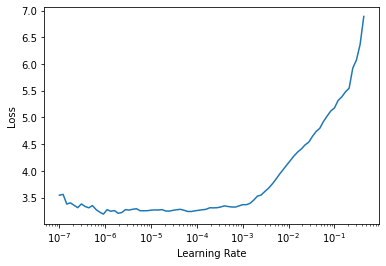

```python
learn.lr_find()
```

Entrenamos durante 5 épocas con el factor de aprendizaje máximo adecuado según la visualización del buscador de factores de aprendizaje.

```python
learn.fit(5, slice(1e-6,1e-4))
learn.save('families3-vgg16-exp3-fepochs1-uepochs5')
```

| epoch | train_loss | valid_loss | custom_accuracy | time |
| --- | --- | --- | --- | --- |
| 0 | 2.807257 | 2.396065 | 0.484431 | 10:11 |
| 1 | 2.496131 | 2.216309 | 0.517363 | 10:12 |
| 2 | 2.355504 | 2.083089 | 0.562218 | 10:12 |
| 3 | 2.130747 | 1.986422 | 0.583922 | 10:13 |
| 4 | 2.000303 | 1.908040 | 0.598796 | 10:12 |

[output not shown]

Defimos una función para continuar el aprendizaje con los pesos guardados.

```python
def continue_training(pth_filename):
    learn = Learner(dls, model, loss_func=loss_func, metrics=custom_accuracy,
                   splitter=custom_splitter).to_fp16()
    learn.load(pth_filename)
    learn.unfreeze()
    return learn
```

```python
learn = continue_training('families3-vgg16-exp3-fepochs1-uepochs5')
```

Continuamos entrenando nuestro modelo hasta las 50 épocas, guardando los pesos del entrenamiento en cada conjunto de épocas.

```python
learn.fit(5, slice(1e-6,1e-4))
learn.save('families3-vgg16-exp3-fepochs1-uepochs10')
```

| epoch | train_loss | valid_loss | custom_accuracy | time |
| --- | --- | --- | --- | --- |
| 0 | 1.883616 | 1.873955 | 0.611471 | 10:22 |
| 1 | 1.781568 | 1.797217 | 0.617201 | 10:17 |
| 2 | 1.791195 | 1.773057 | 0.632249 | 10:18 |
| 3 | 1.652989 | 1.738075 | 0.640120 | 10:17 |
| 4 | 1.569123 | 1.710678 | 0.656268 | 10:17 |

```
Path('models/families3-vgg16-exp3-fepochs1-uepochs10.pth')
```

```python
learn = continue_training('families3-vgg16-exp3-fepochs1-uepochs10')
```

```python
learn.fit(10, slice(1e-6,1e-4))
learn.save('families3-vgg16-exp3-fepochs1-uepochs20')
```

| epoch | train_loss | valid_loss | custom_accuracy | time |
| --- | --- | --- | --- | --- |
| 0 | 1.515997 | 1.690520 | 0.653432 | 10:17 |
| 1 | 1.491300 | 1.678399 | 0.661709 | 10:18 |
| 2 | 1.448118 | 1.659389 | 0.675541 | 10:19 |
| 3 | 1.380612 | 1.638551 | 0.676988 | 10:17 |
| 4 | 1.364486 | 1.632508 | 0.678609 | 10:18 |
| 5 | 1.315754 | 1.618898 | 0.693078 | 10:18 |
| 6 | 1.320021 | 1.612975 | 0.693136 | 10:18 |
| 7 | 1.266651 | 1.592273 | 0.685959 | 10:18 |
| 8 | 1.223034 | 1.594513 | 0.701296 | 10:17 |
| 9 | 1.207386 | 1.620883 | 0.701528 | 10:17 |

```
Path('models/families3-vgg16-exp3-fepochs1-uepochs20.pth')
```

```python
learn = continue_training('families3-vgg16-exp3-fepochs1-uepochs20')
```

```python
learn.fit(10, slice(1e-6,1e-4))
learn.save('families3-vgg16-exp3-fepochs1-uepochs30')
```

| epoch | train_loss | valid_loss | custom_accuracy | time |
| --- | --- | --- | --- | --- |
| 0 | 1.167443 | 1.588274 | 0.711599 | 09:57 |
| 1 | 1.127932 | 1.591632 | 0.716923 | 09:52 |
| 2 | 1.094209 | 1.604789 | 0.708473 | 09:51 |
| 3 | 1.088722 | 1.602651 | 0.719238 | 09:52 |
| 4 | 1.084581 | 1.616425 | 0.715418 | 09:52 |
| 5 | 1.063558 | 1.596955 | 0.722885 | 09:53 |
| 6 | 1.073319 | 1.624534 | 0.725547 | 09:52 |
| 7 | 1.026612 | 1.596906 | 0.729540 | 09:53 |
| 8 | 1.006651 | 1.597081 | 0.738801 | 09:53 |
| 9 | 0.975975 | 1.621697 | 0.733418 | 09:52 |

```
Path('models/families3-vgg16-exp3-fepochs1-uepochs30.pth')
```

```python
learn = continue_training('families3-vgg16-exp3-fepochs1-uepochs30')
```

```python
learn.fit(10, slice(1e-6,1e-4))
learn.save('families3-vgg16-exp3-fepochs1-uepochs40')
```

| epoch | train_loss | valid_loss | custom_accuracy | time |
| --- | --- | --- | --- | --- |
| 0 | 0.995478 | 1.609025 | 0.740711 | 10:08 |
| 1 | 0.951716 | 1.615785 | 0.739264 | 10:03 |
| 2 | 0.971641 | 1.633042 | 0.747656 | 10:04 |
| 3 | 0.953359 | 1.622700 | 0.746151 | 10:03 |
| 4 | 0.940883 | 1.613271 | 0.746556 | 10:05 |
| 5 | 0.942990 | 1.651113 | 0.746383 | 10:04 |
| 6 | 0.905776 | 1.611344 | 0.744588 | 10:05 |
| 7 | 0.910523 | 1.605988 | 0.749797 | 10:04 |
| 8 | 0.915971 | 1.670036 | 0.752228 | 10:05 |
| 9 | 0.897938 | 1.641072 | 0.763109 | 10:04 |

```
Path('models/families3-vgg16-exp3-fepochs1-uepochs40.pth')
```

```python
learn = continue_training('families3-vgg16-exp3-fepochs1-uepochs40')
```

```python
learn.fit(10, slice(1e-6,1e-4))
learn.save('families3-vgg16-exp3-fepochs1-uepochs50')
```

| epoch | train_loss | valid_loss | custom_accuracy | time |
| --- | --- | --- | --- | --- |
| 0 | 0.900371 | 1.681056 | 0.752981 | 09:56 |
| 1 | 0.899791 | 1.635278 | 0.760331 | 09:53 |
| 2 | 0.868884 | 1.660919 | 0.756511 | 09:52 |
| 3 | 0.863673 | 1.683644 | 0.764325 | 09:54 |
| 4 | 0.869039 | 1.670214 | 0.768434 | 09:53 |
| 5 | 0.867880 | 1.627900 | 0.766003 | 09:52 |
| 6 | 0.860034 | 1.650737 | 0.763341 | 09:53 |
| 7 | 0.814705 | 1.702227 | 0.766350 | 09:52 |
| 8 | 0.843230 | 1.661814 | 0.769997 | 09:53 |
| 9 | 0.833802 | 1.674796 | 0.772890 | 09:52 |

```
Path('models/families3-vgg16-exp3-fepochs1-uepochs50.pth')
```

```python
learn.export('families3-vgg16-exp3-fepochs1-uepochs50')
```

## Experimento 4: 1 rama (familia)

Creamos el cuerpo (*encoder*) y cabeza del modelo tomando como base VGG-16 con *Batch Normalization* y con pesos preentrenados.

```python
model = vgg16_bn
body = create_body(model, cut=-2)
body
```

```
Downloading: "https://download.pytorch.org/models/vgg16_bn-6c64b313.pth" to /root/.cache/torch/hub/checkpoints/vgg16_bn-6c64b313.pth
```

```
Sequential(
  (0): Sequential(
    (0): Conv2d(3, 64, kernel_size=(3, 3), stride=(1, 1), padding=(1, 1))
    (1): BatchNorm2d(64, eps=1e-05, momentum=0.1, affine=True, track_running_stats=True)
    (2): ReLU(inplace=True)
    (3): Conv2d(64, 64, kernel_size=(3, 3), stride=(1, 1), padding=(1, 1))
    (4): BatchNorm2d(64, eps=1e-05, momentum=0.1, affine=True, track_running_stats=True)
    (5): ReLU(inplace=True)
    (6): MaxPool2d(kernel_size=2, stride=2, padding=0, dilation=1, ceil_mode=False)
    (7): Conv2d(64, 128, kernel_size=(3, 3), stride=(1, 1), padding=(1, 1))
    (8): BatchNorm2d(128, eps=1e-05, momentum=0.1, affine=True, track_running_stats=True)
    (9): ReLU(inplace=True)
    (10): Conv2d(128, 128, kernel_size=(3, 3), stride=(1, 1), padding=(1, 1))
    (11): BatchNorm2d(128, eps=1e-05, momentum=0.1, affine=True, track_running_stats=True)
    (12): ReLU(inplace=True)
    (13): MaxPool2d(kernel_size=2, stride=2, padding=0, dilation=1, ceil_mode=False)
    (14): Conv2d(128, 256, kernel_size=(3, 3), stride=(1, 1), padding=(1, 1))
    (15): BatchNorm2d(256, eps=1e-05, momentum=0.1, affine=True, track_running_stats=True)
    (16): ReLU(inplace=True)
    (17): Conv2d(256, 256, kernel_size=(3, 3), stride=(1, 1), padding=(1, 1))
    (18): BatchNorm2d(256, eps=1e-05, momentum=0.1, affine=True, track_running_stats=True)
    (19): ReLU(inplace=True)
    (20): Conv2d(256, 256, kernel_size=(3, 3), stride=(1, 1), padding=(1, 1))
    (21): BatchNorm2d(256, eps=1e-05, momentum=0.1, affine=True, track_running_stats=True)
    (22): ReLU(inplace=True)
    (23): MaxPool2d(kernel_size=2, stride=2, padding=0, dilation=1, ceil_mode=False)
    (24): Conv2d(256, 512, kernel_size=(3, 3), stride=(1, 1), padding=(1, 1))
    (25): BatchNorm2d(512, eps=1e-05, momentum=0.1, affine=True, track_running_stats=True)
    (26): ReLU(inplace=True)
    (27): Conv2d(512, 512, kernel_size=(3, 3), stride=(1, 1), padding=(1, 1))
    (28): BatchNorm2d(512, eps=1e-05, momentum=0.1, affine=True, track_running_stats=True)
    (29): ReLU(inplace=True)
    (30): Conv2d(512, 512, kernel_size=(3, 3), stride=(1, 1), padding=(1, 1))
    (31): BatchNorm2d(512, eps=1e-05, momentum=0.1, affine=True, track_running_stats=True)
    (32): ReLU(inplace=True)
    (33): MaxPool2d(kernel_size=2, stride=2, padding=0, dilation=1, ceil_mode=False)
    (34): Conv2d(512, 512, kernel_size=(3, 3), stride=(1, 1), padding=(1, 1))
    (35): BatchNorm2d(512, eps=1e-05, momentum=0.1, affine=True, track_running_stats=True)
    (36): ReLU(inplace=True)
    (37): Conv2d(512, 512, kernel_size=(3, 3), stride=(1, 1), padding=(1, 1))
    (38): BatchNorm2d(512, eps=1e-05, momentum=0.1, affine=True, track_running_stats=True)
    (39): ReLU(inplace=True)
    (40): Conv2d(512, 512, kernel_size=(3, 3), stride=(1, 1), padding=(1, 1))
    (41): BatchNorm2d(512, eps=1e-05, momentum=0.1, affine=True, track_running_stats=True)
    (42): ReLU(inplace=True)
    (43): MaxPool2d(kernel_size=2, stride=2, padding=0, dilation=1, ceil_mode=False)
  )
)
```

```python
head = create_head(512*2,dls.c)
head
```

```
Sequential(
  (0): AdaptiveConcatPool2d(
    (ap): AdaptiveAvgPool2d(output_size=1)
    (mp): AdaptiveMaxPool2d(output_size=1)
  )
  (1): Flatten(full=False)
  (2): BatchNorm1d(1024, eps=1e-05, momentum=0.1, affine=True, track_running_stats=True)
  (3): Dropout(p=0.25, inplace=False)
  (4): Linear(in_features=1024, out_features=512, bias=False)
  (5): ReLU(inplace=True)
  (6): BatchNorm1d(512, eps=1e-05, momentum=0.1, affine=True, track_running_stats=True)
  (7): Dropout(p=0.5, inplace=False)
  (8): Linear(in_features=512, out_features=144, bias=False)
)
```

Separamos el cuerpo de la arquitectura en los distintos bloques para definir cada uno de ellos y aplicar posteriormente una rama entre el bloque 1 y el bloque 2.

```python
_body = body[0]
block1 = _body[:7]
block2 = _body[7:14]
block3 = _body[14:24]
block4 = _body[24:34]
block5 = _body[34:]
```

Definimos una función para obtener las etiquetas de cada ejemplo, en este caso: el familia y la especie.

```python
def custom_get_y(o):
    fine_label = o['Specie']
    coarse1_label = o['Family']
    return [coarse1_label, fine_label]
```

Creamos una clase para nuestro modelo que divida el *encoder* en los distintos bloques y añada una cabeza entre el bloque 1 y 2 como rama con el número de clases de *Family*. En el método *forward* establecemos la conexión de los distintos bloques, separando la salida de la rama del flujo normal, para así devolver ambas salidas en forma de diccionario.

```python
class VGGCustomModel(Module):
    def __init__(self, encoder, head):
        self.encoder = encoder
        encoder = encoder[0]
        self.block1 = encoder[:7]
        self.branch1 = create_head(64*2, len(set(df['Family'])))
        self.block2 = encoder[7:14]
        self.block3 = encoder[14:24]
        self.block4 = encoder[24:34]
        self.block5 = encoder[34:]
        self.head = head

    def forward(self, x):
        x = self.block1(x)
        coarse1_label = self.branch1(x)
        x = self.block2(x)
        x = self.block3(x)
        x = self.block4(x)
        x = self.block5(x)
        fine_label = self.head(x)
        return {
                'fine_label': fine_label,
                'coarse1_label': coarse1_label
               }
```

Creamos el modelo con la clase definida pasándole el cuerpo y cabeza.

```python
model = VGGCustomModel(body, head)
```

Como hemos modificado el modelo y la obtención de las clases para usar una salida múltiple, tenemos que modificar el tipo de bloque de categoría a uno que soporte estas salidas. Para ello, definimos una función que obtenga la clase y codifique a categoría cada una.

```python
class CustomCategorize(DisplayedTransform):
    "Reversible transform of category string to `vocab` id"
    loss_func,order=CrossEntropyLossFlat(),1
    def __init__(self, vocab=None, vocab_coarse1=None, vocab_coarse2=None, sort=True, add_na=False, num_y=1):
        store_attr()
        self.vocab = None if vocab is None else CategoryMap(vocab, sort=sort, add_na=add_na)
        self.vocab_coarse1 = None if vocab_coarse1 is None else CategoryMap(vocab_coarse1, sort=sort, add_na=add_na)

    def setups(self, dsets):
        fine_dsets = [d[1] for d in dsets]
        coarse1_dsets = [d[0] for d in dsets]
        if self.vocab is None and dsets is not None: self.vocab = CategoryMap(fine_dsets, sort=self.sort, add_na=self.add_na)
        if self.vocab_coarse1 is None and dsets is not None: self.vocab_coarse1 = CategoryMap(coarse1_dsets, sort=self.sort, add_na=self.add_na)
        self.c = len(self.vocab)

    def encodes(self, o): return {'fine_label': TensorCategory(self.vocab.o2i[o[1]]),
                                  'coarse1_label': TensorCategory(self.vocab_coarse1.o2i[o[0]])
                                 }
    def decodes(self, o): return Category      (self.vocab    [o])
```

```python
def CustomCategoryBlock(vocab=None, sort=True, add_na=False, num_y=1):
    "`TransformBlock` for single-label categorical targets"
    return TransformBlock(type_tfms=CustomCategorize(vocab=vocab, sort=sort, add_na=add_na))
```

Creamos un *splitter* personalizado con los parámetros de cada bloque y del *head*.

```python
def custom_splitter(model):
    return [params(model.block1),
            params(model.block2),
            params(model.block3),
            params(model.block4),
            params(model.block5),
            params(model.head)]
```

Creamos un *datablock* con: bloques de tipo imagen y categoría personalizada *CustomCategoryBlock*, un separador por columna, la *x* con la columna que contienen la ruta de las imágenes, la *y* con la función personalizada, una transformación para hacer un recorte aleatorio dejando un tamaño común de 336x336, y las transformaciones de aumento de datos por defecto.

```python
fishes = DataBlock(blocks = (ImageBlock, CustomCategoryBlock),
                 splitter=ColSplitter(),
                 get_x = ColReader(5, pref=path),
                 get_y=custom_get_y,
                 item_tfms=RandomResizedCrop(336, min_scale=0.5),
                 batch_tfms=aug_transforms())
dls = fishes.dataloaders(df)
```

Mostramos los *dataloaders* generados con el *datablock*.

```python
dls.train_ds, dls.valid_ds
```

```
((#69110) [(PILImage mode=RGB size=1024x768, {'fine_label': TensorCategory(13), 'coarse1_label': TensorCategory(0)}),(PILImage mode=RGB size=1024x768, {'fine_label': TensorCategory(83), 'coarse1_label': TensorCategory(0)}),(PILImage mode=RGB size=768x1024, {'fine_label': TensorCategory(83), 'coarse1…
 (#17278) [(PILImage mode=RGB size=768x1024, {'fine_label': TensorCategory(83), 'coarse1_label': TensorCategory(0)}),(PILImage mode=RGB size=1024x636, {'fine_label': TensorCategory(83), 'coarse1_label': TensorCategory(0)}),(PILImage mode=RGB size=1024x768, {'fine_label': TensorCategory(52), 'coarse1…
```

Mostramos las clases finas y las categóricas de nuestros dataloaders.

```python
dls.vocab, dls.vocab_coarse1
```

```
(['Abramis brama', 'Abudefduf abdominalis', 'Abudefduf bengalensis', 'Abudefduf saxatilis', 'Abudefduf septemfasciatus', 'Abudefduf sexfasciatus', 'Abudefduf sordidus', 'Abudefduf troschelii', 'Abudefduf vaigiensis', 'Acanthochromis polyacanthus', 'Acrossocheilus paradoxus', 'Alburnus alburnus', 'Al…
 ['Centrarchidae', 'Cyprinidae', 'Pomacentridae'])
```

Creamos el tensor con los pesos por clase y lo pasamos a GPU para poder usarlo durante el entrenamiento.

```python
weights = tensor([float(weights_df[weights_df['Specie']==c]['Weight']) for c in dls.vocab]).cuda()
weights_family = tensor([float(weights_family_df[weights_family_df['Family']==c]['Weight']) for c in dls.vocab_coarse1]).cuda()
```

Defimos nuestra función de pérdida como el sumatorio de la pérdida en entropía cruzada de las dos salidas.

```python
def loss_func(out, targ):
    return nn.CrossEntropyLoss(weight=weights)(out['fine_label'], targ['fine_label']) + \
            nn.CrossEntropyLoss(weight=weights_family)(out['coarse1_label'], targ['coarse1_label'])
```

Defimos la función de accuracy con la etiqueta fina, ya que es el resultado final que nos interesa. Además, esta etiqueta fue la que se usó para definir las particiones estratificadas, por lo que es la única que se debería tener en cuenta si queremos resultados más fiables.

```python
def custom_accuracy(inp, targ, axis=-1):
    pred1,targ1 = flatten_check(inp['fine_label'].argmax(dim=axis), targ['fine_label'])
    acc1 = (pred1 == targ1).float().mean()
    return acc1
```

Creamos nuestro objeto *Learner* con los *dataloaders*, la función de pérdida _loss*func* creada, la métrica exactitud y el *splitter* creado. Además, congelamos nuestro modelo para ajustar primero los pesos preentrenados a nuestras clases.

```python
learn = Learner(dls, model, loss_func=loss_func, metrics=custom_accuracy,
                   splitter=custom_splitter).to_fp16()
learn.freeze()
```

Mostramos un resumen de nuestro modelo.

```python
learn.summary()
```

| epoch | train_loss | valid_loss | custom_accuracy | time |
| --- | --- | --- | --- | --- |
| 0 | None | None | 00:00 |  |

```
VGGCustomModel (Input shape: ['64 x 3 x 336 x 336'])
================================================================
Layer (type)         Output Shape         Param #    Trainable
================================================================
Conv2d               64 x 64 x 336 x 336  1,792      False
________________________________________________________________
BatchNorm2d          64 x 64 x 336 x 336  128        True
________________________________________________________________
ReLU                 64 x 64 x 336 x 336  0          False
________________________________________________________________
Conv2d               64 x 64 x 336 x 336  36,928     False
________________________________________________________________
BatchNorm2d          64 x 64 x 336 x 336  128        True
________________________________________________________________
ReLU                 64 x 64 x 336 x 336  0          False
________________________________________________________________
MaxPool2d            64 x 64 x 168 x 168  0          False
________________________________________________________________
Conv2d               64 x 128 x 168 x 16  73,856     False
________________________________________________________________
BatchNorm2d          64 x 128 x 168 x 16  256        True
________________________________________________________________
ReLU                 64 x 128 x 168 x 16  0          False
________________________________________________________________
Conv2d               64 x 128 x 168 x 16  147,584    False
________________________________________________________________
BatchNorm2d          64 x 128 x 168 x 16  256        True
________________________________________________________________
ReLU                 64 x 128 x 168 x 16  0          False
________________________________________________________________
MaxPool2d            64 x 128 x 84 x 84   0          False
________________________________________________________________
Conv2d               64 x 256 x 84 x 84   295,168    False
________________________________________________________________
BatchNorm2d          64 x 256 x 84 x 84   512        True
________________________________________________________________
ReLU                 64 x 256 x 84 x 84   0          False
________________________________________________________________
Conv2d               64 x 256 x 84 x 84   590,080    False
________________________________________________________________
```

[output cut: 181 more lines]

```
Total params: 30,115,712
Total trainable params: 686,336
Total non-trainable params: 29,429,376

Optimizer used: <function Adam at 0x7fb61d783160>
Loss function: <function loss_func at 0x7fb61c44e0d0>

Model frozen up to parameter group #5

Callbacks:
  - ModelToHalf
  - TrainEvalCallback
  - Recorder
  - ProgressCallback
  - MixedPrecision
```

Entrenamos el modelo congelado para ajustar los pesos de las últimas capas a nuestras clases, y descongelamos el modelo.

```python
learn.fit(1, 3e-3)
learn.save('families3-vgg16-exp4-fepochs1-uepochs0')
```

| epoch | train_loss | valid_loss | custom_accuracy | time |
| --- | --- | --- | --- | --- |
| 0 | 3.917582 | 3.336968 | 0.350272 | 08:45 |

```
Path('models/families3-vgg16-exp4-fepochs1-uepochs0.pth')
```

```python
learn.unfreeze()
```

Buscamos el factor de aprendizaje más adecuado con lr_find.

```
SuggestedLRs(lr_min=3.311311302240938e-05, lr_steep=3.311311274956097e-06)
```

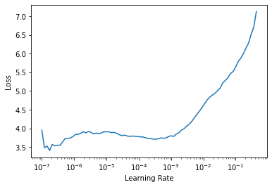

```python
learn.lr_find()
```

Entrenamos durante 10 épocas con el factor de aprendizaje máximo adecuado según la visualización del buscador de factores de aprendizaje.

```python
learn.fit(10, slice(1e-6,1e-4))
learn.save('families3-vgg16-exp4-fepochs1-uepochs10')
```

| epoch | train_loss | valid_loss | custom_accuracy | time |
| --- | --- | --- | --- | --- |
| 0 | 3.159892 | 2.740967 | 0.493170 | 10:11 |
| 1 | 2.889957 | 2.568150 | 0.519157 | 10:11 |
| 2 | 2.704166 | 2.439982 | 0.547691 | 10:12 |
| 3 | 2.626744 | 2.343104 | 0.566617 | 10:13 |
| 4 | 2.389676 | 2.278805 | 0.583922 | 10:12 |
| 5 | 2.288326 | 2.220843 | 0.619921 | 10:11 |
| 6 | 2.199508 | 2.195167 | 0.621773 | 10:11 |
| 7 | 2.147992 | 2.125933 | 0.634217 | 10:11 |
| 8 | 2.083087 | 2.114920 | 0.638268 | 10:11 |
| 9 | 2.009008 | 2.104352 | 0.651522 | 10:12 |

```
Path('models/families3-vgg16-exp4-fepochs1-uepochs10.pth')
```

Defimos una función para continuar el aprendizaje con los pesos guardados.

```python
def continue_training(pth_filename):
    learn = Learner(dls, model, loss_func=loss_func, metrics=custom_accuracy,
                   splitter=custom_splitter).to_fp16()
    learn.load(pth_filename)
    learn.unfreeze()
    return learn
```

```python
learn = continue_training('families3-vgg16-exp4-fepochs1-uepochs10')
```

Continuamos entrenando nuestro modelo hasta las 50 épocas, guardando los pesos del entrenamiento en cada 10 épocas.

```python
learn.fit(10, slice(1e-6,1e-4))
learn.save('families3-vgg16-exp4-fepochs1-uepochs20')
```

| epoch | train_loss | valid_loss | custom_accuracy | time |
| --- | --- | --- | --- | --- |
| 0 | 1.961239 | 2.070387 | 0.651464 | 10:00 |
| 1 | 1.889718 | 2.041723 | 0.664545 | 09:56 |
| 2 | 1.850736 | 2.008577 | 0.669290 | 09:56 |
| 3 | 1.785617 | 1.999984 | 0.684049 | 09:56 |
| 4 | 1.775091 | 2.017608 | 0.676872 | 09:55 |
| 5 | 1.701738 | 1.985222 | 0.693772 | 09:56 |
| 6 | 1.655286 | 1.995806 | 0.694988 | 09:56 |
| 7 | 1.615266 | 2.006262 | 0.697650 | 09:56 |
| 8 | 1.635262 | 2.000114 | 0.711251 | 09:55 |
| 9 | 1.588190 | 1.980427 | 0.709457 | 09:56 |

```
Path('models/families3-vgg16-exp4-fepochs1-uepochs20.pth')
```

```python
learn = continue_training('families3-vgg16-exp4-fepochs1-uepochs20')
```

```python
learn.fit(10, slice(1e-6,1e-4))
learn.save('families3-vgg16-exp4-fepochs1-uepochs30')
```

| epoch | train_loss | valid_loss | custom_accuracy | time |
| --- | --- | --- | --- | --- |
| 0 | 1.558673 | 1.994194 | 0.709689 | 09:57 |
| 1 | 1.545245 | 1.980563 | 0.718544 | 09:52 |
| 2 | 1.500954 | 1.991768 | 0.722306 | 09:53 |
| 3 | 1.503029 | 1.976543 | 0.716344 | 09:53 |
| 4 | 1.488356 | 1.966724 | 0.727978 | 09:53 |
| 5 | 1.474430 | 1.957350 | 0.726126 | 09:53 |
| 6 | 1.450788 | 1.969802 | 0.727225 | 09:53 |
| 7 | 1.418925 | 1.992634 | 0.736254 | 09:53 |
| 8 | 1.373525 | 1.987471 | 0.735791 | 09:53 |
| 9 | 1.394391 | 1.985172 | 0.746730 | 09:52 |

```
Path('models/families3-vgg16-exp4-fepochs1-uepochs30.pth')
```

```python
learn = continue_training('families3-vgg16-exp4-fepochs1-uepochs30')
```

```python
learn.fit(10, slice(1e-6,1e-4))
learn.save('families3-vgg16-exp4-fepochs1-uepochs40')
```

| epoch | train_loss | valid_loss | custom_accuracy | time |
| --- | --- | --- | --- | --- |
| 0 | 1.409050 | 1.989555 | 0.736775 | 10:30 |
| 1 | 1.364948 | 1.988060 | 0.745804 | 10:25 |
| 2 | 1.383098 | 2.013899 | 0.751013 | 10:25 |
| 3 | 1.367347 | 1.998758 | 0.744820 | 10:27 |
| 4 | 1.353234 | 2.010996 | 0.751360 | 10:27 |
| 5 | 1.359251 | 1.995066 | 0.749334 | 10:27 |
| 6 | 1.347133 | 2.028547 | 0.753270 | 10:26 |
| 7 | 1.287434 | 2.013245 | 0.755412 | 10:27 |
| 8 | 1.298100 | 2.013792 | 0.756280 | 10:27 |
| 9 | 1.301690 | 2.023895 | 0.760100 | 10:25 |

```
Path('models/families3-vgg16-exp4-fepochs1-uepochs40.pth')
```

```python
learn = continue_training('families3-vgg16-exp4-fepochs1-uepochs40')
```

```python
learn.fit(10, slice(1e-6,1e-4))
learn.save('families3-vgg16-exp4-fepochs1-uepochs50')
```

| epoch | train_loss | valid_loss | custom_accuracy | time |
| --- | --- | --- | --- | --- |
| 0 | 1.294162 | 2.024383 | 0.766119 | 10:09 |
| 1 | 1.290114 | 1.977262 | 0.763977 | 10:09 |
| 2 | 1.270398 | 2.038795 | 0.765308 | 10:03 |
| 3 | 1.252025 | 2.039196 | 0.766177 | 10:05 |
| 4 | 1.284658 | 1.995716 | 0.762993 | 10:04 |
| 5 | 1.271981 | 2.024003 | 0.767450 | 10:05 |
| 6 | 1.288185 | 2.072525 | 0.769071 | 10:06 |
| 7 | 1.238101 | 2.036612 | 0.770923 | 10:02 |
| 8 | 1.254814 | 2.023995 | 0.772080 | 10:06 |
| 9 | 1.208529 | 2.053729 | 0.773469 | 10:06 |

```
Path('models/families3-vgg16-exp4-fepochs1-uepochs50.pth')
```

```python
learn.export('families3-vgg16-exp4-fepochs1-uepochs50')
```

## Experimento 5: 1 Rama (familia)

Creamos el cuerpo (*encoder*) y cabeza del modelo tomando como base VGG-16 con *Batch Normalization* y con pesos preentrenados.

```python
model = vgg16_bn
body = create_body(model, cut=-2)
body
```

```
Downloading: "https://download.pytorch.org/models/vgg16_bn-6c64b313.pth" to /root/.cache/torch/hub/checkpoints/vgg16_bn-6c64b313.pth
```

```
Sequential(
  (0): Sequential(
    (0): Conv2d(3, 64, kernel_size=(3, 3), stride=(1, 1), padding=(1, 1))
    (1): BatchNorm2d(64, eps=1e-05, momentum=0.1, affine=True, track_running_stats=True)
    (2): ReLU(inplace=True)
    (3): Conv2d(64, 64, kernel_size=(3, 3), stride=(1, 1), padding=(1, 1))
    (4): BatchNorm2d(64, eps=1e-05, momentum=0.1, affine=True, track_running_stats=True)
    (5): ReLU(inplace=True)
    (6): MaxPool2d(kernel_size=2, stride=2, padding=0, dilation=1, ceil_mode=False)
    (7): Conv2d(64, 128, kernel_size=(3, 3), stride=(1, 1), padding=(1, 1))
    (8): BatchNorm2d(128, eps=1e-05, momentum=0.1, affine=True, track_running_stats=True)
    (9): ReLU(inplace=True)
    (10): Conv2d(128, 128, kernel_size=(3, 3), stride=(1, 1), padding=(1, 1))
    (11): BatchNorm2d(128, eps=1e-05, momentum=0.1, affine=True, track_running_stats=True)
    (12): ReLU(inplace=True)
    (13): MaxPool2d(kernel_size=2, stride=2, padding=0, dilation=1, ceil_mode=False)
    (14): Conv2d(128, 256, kernel_size=(3, 3), stride=(1, 1), padding=(1, 1))
    (15): BatchNorm2d(256, eps=1e-05, momentum=0.1, affine=True, track_running_stats=True)
    (16): ReLU(inplace=True)
    (17): Conv2d(256, 256, kernel_size=(3, 3), stride=(1, 1), padding=(1, 1))
    (18): BatchNorm2d(256, eps=1e-05, momentum=0.1, affine=True, track_running_stats=True)
    (19): ReLU(inplace=True)
    (20): Conv2d(256, 256, kernel_size=(3, 3), stride=(1, 1), padding=(1, 1))
    (21): BatchNorm2d(256, eps=1e-05, momentum=0.1, affine=True, track_running_stats=True)
    (22): ReLU(inplace=True)
    (23): MaxPool2d(kernel_size=2, stride=2, padding=0, dilation=1, ceil_mode=False)
    (24): Conv2d(256, 512, kernel_size=(3, 3), stride=(1, 1), padding=(1, 1))
    (25): BatchNorm2d(512, eps=1e-05, momentum=0.1, affine=True, track_running_stats=True)
    (26): ReLU(inplace=True)
    (27): Conv2d(512, 512, kernel_size=(3, 3), stride=(1, 1), padding=(1, 1))
    (28): BatchNorm2d(512, eps=1e-05, momentum=0.1, affine=True, track_running_stats=True)
    (29): ReLU(inplace=True)
    (30): Conv2d(512, 512, kernel_size=(3, 3), stride=(1, 1), padding=(1, 1))
    (31): BatchNorm2d(512, eps=1e-05, momentum=0.1, affine=True, track_running_stats=True)
    (32): ReLU(inplace=True)
    (33): MaxPool2d(kernel_size=2, stride=2, padding=0, dilation=1, ceil_mode=False)
    (34): Conv2d(512, 512, kernel_size=(3, 3), stride=(1, 1), padding=(1, 1))
    (35): BatchNorm2d(512, eps=1e-05, momentum=0.1, affine=True, track_running_stats=True)
    (36): ReLU(inplace=True)
    (37): Conv2d(512, 512, kernel_size=(3, 3), stride=(1, 1), padding=(1, 1))
    (38): BatchNorm2d(512, eps=1e-05, momentum=0.1, affine=True, track_running_stats=True)
    (39): ReLU(inplace=True)
    (40): Conv2d(512, 512, kernel_size=(3, 3), stride=(1, 1), padding=(1, 1))
    (41): BatchNorm2d(512, eps=1e-05, momentum=0.1, affine=True, track_running_stats=True)
    (42): ReLU(inplace=True)
    (43): MaxPool2d(kernel_size=2, stride=2, padding=0, dilation=1, ceil_mode=False)
  )
)
```

```python
head = create_head(512*2,dls.c)
head
```

```
Sequential(
  (0): AdaptiveConcatPool2d(
    (ap): AdaptiveAvgPool2d(output_size=1)
    (mp): AdaptiveMaxPool2d(output_size=1)
  )
  (1): Flatten(full=False)
  (2): BatchNorm1d(1024, eps=1e-05, momentum=0.1, affine=True, track_running_stats=True)
  (3): Dropout(p=0.25, inplace=False)
  (4): Linear(in_features=1024, out_features=512, bias=False)
  (5): ReLU(inplace=True)
  (6): BatchNorm1d(512, eps=1e-05, momentum=0.1, affine=True, track_running_stats=True)
  (7): Dropout(p=0.5, inplace=False)
  (8): Linear(in_features=512, out_features=144, bias=False)
)
```

Separamos el cuerpo de la arquitectura en los distintos bloques para definir cada uno de ellos y aplicar posteriormente una rama entre el bloque 2 y el bloque 3.

```python
_body = body[0]
block1 = _body[:7]
block2 = _body[7:14]
block3 = _body[14:24]
block4 = _body[24:34]
block5 = _body[34:]
```

Definimos una función para obtener las etiquetas de cada ejemplo, en este caso: el familia y la especie.

```python
def custom_get_y(o):
    fine_label = o['Specie']
    coarse1_label = o['Family']
    return [coarse1_label, fine_label]
```

Creamos una clase para nuestro modelo que divida el *encoder* en los distintos bloques y añada una cabeza entre el bloque 2 y 3 como rama con el número de clases de *Family*. En el método *forward* establecemos la conexión de los distintos bloques, separando la salida de la rama del flujo normal, para así devolver ambas salidas en forma de diccionario.

```python
class VGGCustomModel(Module):
    def __init__(self, encoder, head):
        self.encoder = encoder
        encoder = encoder[0]
        self.block1 = encoder[:7]
        self.block2 = encoder[7:14]
        self.branch1 = create_head(128*2, len(set(df['Family'])))
        self.block3 = encoder[14:24]
        self.block4 = encoder[24:34]
        self.block5 = encoder[34:]
        self.head = head

    def forward(self, x):
        x = self.block1(x)
        x = self.block2(x)
        coarse1_label = self.branch1(x)
        x = self.block3(x)
        x = self.block4(x)
        x = self.block5(x)
        fine_label = self.head(x)
        return {
                'fine_label': fine_label,
                'coarse1_label': coarse1_label
               }
```

Creamos el modelo con la clase definida pasándole el cuerpo y cabeza.

```python
model = VGGCustomModel(body, head)
```

Como hemos modificado el modelo y la obtención de las clases para usar una salida múltiple, tenemos que modificar el tipo de bloque de categoría a uno que soporte estas salidas. Para ello, definimos una función que obtenga la clase y codifique a categoría cada una.

```python
class CustomCategorize(DisplayedTransform):
    "Reversible transform of category string to `vocab` id"
    loss_func,order=CrossEntropyLossFlat(),1
    def __init__(self, vocab=None, vocab_coarse1=None, vocab_coarse2=None, sort=True, add_na=False, num_y=1):
        store_attr()
        self.vocab = None if vocab is None else CategoryMap(vocab, sort=sort, add_na=add_na)
        self.vocab_coarse1 = None if vocab_coarse1 is None else CategoryMap(vocab_coarse1, sort=sort, add_na=add_na)

    def setups(self, dsets):
        fine_dsets = [d[1] for d in dsets]
        coarse1_dsets = [d[0] for d in dsets]
        if self.vocab is None and dsets is not None: self.vocab = CategoryMap(fine_dsets, sort=self.sort, add_na=self.add_na)
        if self.vocab_coarse1 is None and dsets is not None: self.vocab_coarse1 = CategoryMap(coarse1_dsets, sort=self.sort, add_na=self.add_na)
        self.c = len(self.vocab)

    def encodes(self, o): return {'fine_label': TensorCategory(self.vocab.o2i[o[1]]),
                                  'coarse1_label': TensorCategory(self.vocab_coarse1.o2i[o[0]])
                                 }
    def decodes(self, o): return Category      (self.vocab    [o])
```

```python
def CustomCategoryBlock(vocab=None, sort=True, add_na=False, num_y=1):
    "`TransformBlock` for single-label categorical targets"
    return TransformBlock(type_tfms=CustomCategorize(vocab=vocab, sort=sort, add_na=add_na))
```

Creamos un *splitter* personalizado con los parámetros de cada bloque y del *head*.

```python
def custom_splitter(model):
    return [params(model.block1),
            params(model.block2),
            params(model.block3),
            params(model.block4),
            params(model.block5),
            params(model.head)]
```

Creamos un *datablock* con: bloques de tipo imagen y categoría personalizada *CustomCategoryBlock*, un separador por columna, la *x* con la columna que contienen la ruta de las imágenes, la *y* con la función personalizada, una transformación para hacer un recorte aleatorio dejando un tamaño común de 336x336, y las transformaciones de aumento de datos por defecto.

```python
fishes = DataBlock(blocks = (ImageBlock, CustomCategoryBlock),
                 splitter=ColSplitter(),
                 get_x = ColReader(5, pref=path),
                 get_y=custom_get_y,
                 item_tfms=RandomResizedCrop(336, min_scale=0.5),
                 batch_tfms=aug_transforms())
dls = fishes.dataloaders(df)
```

Mostramos los *dataloaders* generados con el *datablock*.

```python
dls.train_ds, dls.valid_ds
```

```
((#69110) [(PILImage mode=RGB size=1024x768, {'fine_label': TensorCategory(13), 'coarse1_label': TensorCategory(0)}),(PILImage mode=RGB size=1024x768, {'fine_label': TensorCategory(83), 'coarse1_label': TensorCategory(0)}),(PILImage mode=RGB size=768x1024, {'fine_label': TensorCategory(83), 'coarse1…
 (#17278) [(PILImage mode=RGB size=768x1024, {'fine_label': TensorCategory(83), 'coarse1_label': TensorCategory(0)}),(PILImage mode=RGB size=1024x636, {'fine_label': TensorCategory(83), 'coarse1_label': TensorCategory(0)}),(PILImage mode=RGB size=1024x768, {'fine_label': TensorCategory(52), 'coarse1…
```

Mostramos las clases finas y las categóricas de nuestros dataloaders.

```python
dls.vocab, dls.vocab_coarse1
```

```
(['Abramis brama', 'Abudefduf abdominalis', 'Abudefduf bengalensis', 'Abudefduf saxatilis', 'Abudefduf septemfasciatus', 'Abudefduf sexfasciatus', 'Abudefduf sordidus', 'Abudefduf troschelii', 'Abudefduf vaigiensis', 'Acanthochromis polyacanthus', 'Acrossocheilus paradoxus', 'Alburnus alburnus', 'Al…
 ['Centrarchidae', 'Cyprinidae', 'Pomacentridae'])
```

Creamos el tensor con los pesos por clase y lo pasamos a GPU para poder usarlo durante el entrenamiento.

```python
weights = tensor([float(weights_df[weights_df['Specie']==c]['Weight']) for c in dls.vocab]).cuda()
weights_family = tensor([float(weights_family_df[weights_family_df['Family']==c]['Weight']) for c in dls.vocab_coarse1]).cuda()
```

Defimos nuestra función de pérdida como el sumatorio de la pérdida en entropía cruzada de las dos salidas.

```python
def loss_func(out, targ):
    return nn.CrossEntropyLoss(weight=weights)(out['fine_label'], targ['fine_label']) + \
            nn.CrossEntropyLoss(weight=weights_family)(out['coarse1_label'], targ['coarse1_label'])
```

Defimos la función de accuracy con la etiqueta fina, ya que es el resultado final que nos interesa. Además, esta etiqueta fue la que se usó para definir las particiones estratificadas, por lo que es la única que se debería tener en cuenta si queremos resultados más fiables.

```python
def custom_accuracy(inp, targ, axis=-1):
    pred1,targ1 = flatten_check(inp['fine_label'].argmax(dim=axis), targ['fine_label'])
    acc1 = (pred1 == targ1).float().mean()
    return acc1
```

Creamos nuestro objeto *Learner* con los *dataloaders*, la función de pérdida _loss*func* creada, la métrica exactitud y el *splitter* creado. Además, congelamos nuestro modelo para ajustar primero los pesos preentrenados a nuestras clases.

```python
learn = Learner(dls, model, loss_func=loss_func, metrics=custom_accuracy,
                   splitter=custom_splitter).to_fp16()
learn.freeze()
```

Mostramos un resumen de nuestro modelo.

```python
learn.summary()
```

| epoch | train_loss | valid_loss | custom_accuracy | time |
| --- | --- | --- | --- | --- |
| 0 | None | None | 00:00 |  |

```
VGGCustomModel (Input shape: ['64 x 3 x 336 x 336'])
================================================================
Layer (type)         Output Shape         Param #    Trainable
================================================================
Conv2d               64 x 64 x 336 x 336  1,792      False
________________________________________________________________
BatchNorm2d          64 x 64 x 336 x 336  128        True
________________________________________________________________
ReLU                 64 x 64 x 336 x 336  0          False
________________________________________________________________
Conv2d               64 x 64 x 336 x 336  36,928     False
________________________________________________________________
BatchNorm2d          64 x 64 x 336 x 336  128        True
________________________________________________________________
ReLU                 64 x 64 x 336 x 336  0          False
________________________________________________________________
MaxPool2d            64 x 64 x 168 x 168  0          False
________________________________________________________________
Conv2d               64 x 128 x 168 x 16  73,856     False
________________________________________________________________
BatchNorm2d          64 x 128 x 168 x 16  256        True
________________________________________________________________
ReLU                 64 x 128 x 168 x 16  0          False
________________________________________________________________
Conv2d               64 x 128 x 168 x 16  147,584    False
________________________________________________________________
BatchNorm2d          64 x 128 x 168 x 16  256        True
________________________________________________________________
ReLU                 64 x 128 x 168 x 16  0          False
________________________________________________________________
MaxPool2d            64 x 128 x 84 x 84   0          False
________________________________________________________________
Conv2d               64 x 256 x 84 x 84   295,168    False
________________________________________________________________
BatchNorm2d          64 x 256 x 84 x 84   512        True
________________________________________________________________
ReLU                 64 x 256 x 84 x 84   0          False
________________________________________________________________
Conv2d               64 x 256 x 84 x 84   590,080    False
________________________________________________________________
```

[output cut: 181 more lines]

```
Total params: 30,181,504
Total trainable params: 752,128
Total non-trainable params: 29,429,376

Optimizer used: <function Adam at 0x7f5bb896b160>
Loss function: <function loss_func at 0x7f5bb763c160>

Model frozen up to parameter group #5

Callbacks:
  - ModelToHalf
  - TrainEvalCallback
  - Recorder
  - ProgressCallback
  - MixedPrecision
```

Entrenamos el modelo congelado para ajustar los pesos de las últimas capas a nuestras clases, y descongelamos el modelo.

```python
learn.fit(1, 3e-3)
learn.save('families3-vgg16-exp5-fepochs1-uepochs0')
```

| epoch | train_loss | valid_loss | custom_accuracy | time |
| --- | --- | --- | --- | --- |
| 0 | 3.901951 | 3.313489 | 0.338581 | 08:38 |

```
Path('models/families3-vgg16-exp5-fepochs1-uepochs0.pth')
```

```python
learn.unfreeze()
```

Buscamos el factor de aprendizaje más adecuado con lr_find.

```
SuggestedLRs(lr_min=4.786300996784121e-05, lr_steep=9.12010818865383e-07)
```

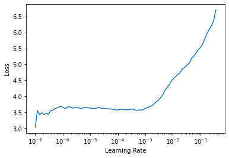

```python
learn.lr_find()
```

Entrenamos durante 10 épocas con el factor de aprendizaje máximo adecuado según la visualización del buscador de factores de aprendizaje.

```python
learn.fit(10, slice(1e-6,1e-4))
learn.save('families3-vgg16-exp5-fepochs1-uepochs10')
```

| epoch | train_loss | valid_loss | custom_accuracy | time |
| --- | --- | --- | --- | --- |
| 0 | 3.099352 | 2.663053 | 0.465737 | 10:05 |
| 1 | 2.782991 | 2.463645 | 0.527550 | 10:05 |
| 2 | 2.566589 | 2.321128 | 0.546533 | 10:05 |
| 3 | 2.445042 | 2.211682 | 0.560539 | 10:06 |
| 4 | 2.342044 | 2.153587 | 0.595555 | 10:06 |
| 5 | 2.198071 | 2.072296 | 0.597754 | 10:07 |
| 6 | 2.082581 | 2.004022 | 0.619227 | 10:07 |
| 7 | 2.012550 | 1.982582 | 0.623741 | 10:06 |
| 8 | 1.924539 | 1.934698 | 0.642898 | 10:07 |
| 9 | 1.896197 | 1.899655 | 0.647587 | 10:07 |

```
Path('models/families3-vgg16-exp5-fepochs1-uepochs10.pth')
```

Defimos una función para continuar el aprendizaje con los pesos guardados.

```python
def continue_training(pth_filename):
    learn = Learner(dls, model, loss_func=loss_func, metrics=custom_accuracy,
                   splitter=custom_splitter).to_fp16()
    learn.load(pth_filename)
    learn.unfreeze()
    return learn
```

```python
learn = continue_training('families3-vgg16-exp5-fepochs1-uepochs10')
```

Continuamos entrenando nuestro modelo hasta las 50 épocas, guardando los pesos del entrenamiento en cada 10 épocas.

```python
learn.fit(10, slice(1e-6,1e-4))
learn.save('families3-vgg16-exp5-fepochs1-uepochs20')
```

| epoch | train_loss | valid_loss | custom_accuracy | time |
| --- | --- | --- | --- | --- |
| 0 | 1.819870 | 1.881699 | 0.656442 | 10:06 |
| 1 | 1.691012 | 1.866659 | 0.667381 | 10:02 |
| 2 | 1.673764 | 1.853373 | 0.675831 | 10:02 |
| 3 | 1.647721 | 1.830524 | 0.666223 | 10:01 |
| 4 | 1.585810 | 1.821643 | 0.683644 | 10:01 |
| 5 | 1.533934 | 1.806010 | 0.687001 | 10:03 |
| 6 | 1.508142 | 1.783199 | 0.698287 | 10:04 |
| 7 | 1.489172 | 1.774382 | 0.700023 | 10:04 |
| 8 | 1.465030 | 1.769906 | 0.695451 | 10:02 |
| 9 | 1.417047 | 1.782158 | 0.708415 | 10:04 |

```
Path('models/families3-vgg16-exp5-fepochs1-uepochs20.pth')
```

```python
learn = continue_training('families3-vgg16-exp5-fepochs1-uepochs20')
```

```python
learn.fit(10, slice(1e-6,1e-4))
learn.save('families3-vgg16-exp5-fepochs1-uepochs30')
```

| epoch | train_loss | valid_loss | custom_accuracy | time |
| --- | --- | --- | --- | --- |
| 0 | 1.392863 | 1.759252 | 0.702743 | 10:08 |
| 1 | 1.358732 | 1.779112 | 0.717965 | 10:05 |
| 2 | 1.361154 | 1.768679 | 0.717849 | 10:05 |
| 3 | 1.328878 | 1.780255 | 0.716923 | 10:04 |
| 4 | 1.298182 | 1.787011 | 0.720859 | 10:06 |
| 5 | 1.291537 | 1.737403 | 0.721785 | 10:06 |
| 6 | 1.261035 | 1.738850 | 0.730814 | 10:05 |
| 7 | 1.252925 | 1.725597 | 0.730409 | 10:07 |
| 8 | 1.223949 | 1.738595 | 0.742563 | 10:05 |
| 9 | 1.209503 | 1.787569 | 0.744820 | 10:01 |

```
Path('models/families3-vgg16-exp5-fepochs1-uepochs30.pth')
```

```python
learn = continue_training('families3-vgg16-exp5-fepochs1-uepochs30')
```

```python
learn.fit(10, slice(1e-6,1e-4))
learn.save('families3-vgg16-exp5-fepochs1-uepochs40')
```

| epoch | train_loss | valid_loss | custom_accuracy | time |
| --- | --- | --- | --- | --- |
| 0 | 1.194232 | 1.759310 | 0.740942 | 09:58 |
| 1 | 1.147835 | 1.743821 | 0.741463 | 09:54 |
| 2 | 1.161917 | 1.745494 | 0.747077 | 09:54 |
| 3 | 1.160341 | 1.767759 | 0.749913 | 09:54 |
| 4 | 1.161748 | 1.736207 | 0.752055 | 09:54 |
| 5 | 1.138429 | 1.744382 | 0.755180 | 09:55 |
| 6 | 1.107431 | 1.767798 | 0.748293 | 09:56 |
| 7 | 1.131402 | 1.761596 | 0.748177 | 09:56 |
| 8 | 1.104228 | 1.792608 | 0.756685 | 09:56 |
| 9 | 1.051318 | 1.774258 | 0.764556 | 09:56 |

```
Path('models/families3-vgg16-exp5-fepochs1-uepochs40.pth')
```

```python
learn = continue_training('families3-vgg16-exp5-fepochs1-uepochs40')
```

```python
learn.fit(10, slice(1e-6,1e-4))
learn.save('families3-vgg16-exp5-fepochs1-uepochs50')
```

| epoch | train_loss | valid_loss | custom_accuracy | time |
| --- | --- | --- | --- | --- |
| 0 | 1.084410 | 1.786469 | 0.755932 | 10:10 |
| 1 | 1.065998 | 1.815906 | 0.761431 | 10:06 |
| 2 | 1.063172 | 1.777993 | 0.754717 | 10:08 |
| 3 | 1.086902 | 1.754142 | 0.763225 | 10:08 |
| 4 | 1.060846 | 1.783137 | 0.761257 | 10:09 |
| 5 | 1.026784 | 1.793226 | 0.775958 | 10:08 |
| 6 | 1.034365 | 1.843774 | 0.765193 | 10:08 |
| 7 | 1.024398 | 1.797823 | 0.769071 | 10:08 |
| 8 | 1.011193 | 1.798778 | 0.771733 | 10:08 |
| 9 | 1.001791 | 1.778756 | 0.769591 | 10:10 |

```
Path('models/families3-vgg16-exp5-fepochs1-uepochs50.pth')
```

```python
learn.export('families3-vgg16-exp5-fepochs1-uepochs50')
```

## Experimento 6: 1 Rama (género)

Creamos el cuerpo (*encoder*) y cabeza del modelo tomando como base VGG-16 con *Batch Normalization* y con pesos preentrenados.

```python
model = vgg16_bn
body = create_body(model, cut=-2)
body
```

```
Downloading: "https://download.pytorch.org/models/vgg16_bn-6c64b313.pth" to /root/.cache/torch/hub/checkpoints/vgg16_bn-6c64b313.pth
```

```
Sequential(
  (0): Sequential(
    (0): Conv2d(3, 64, kernel_size=(3, 3), stride=(1, 1), padding=(1, 1))
    (1): BatchNorm2d(64, eps=1e-05, momentum=0.1, affine=True, track_running_stats=True)
    (2): ReLU(inplace=True)
    (3): Conv2d(64, 64, kernel_size=(3, 3), stride=(1, 1), padding=(1, 1))
    (4): BatchNorm2d(64, eps=1e-05, momentum=0.1, affine=True, track_running_stats=True)
    (5): ReLU(inplace=True)
    (6): MaxPool2d(kernel_size=2, stride=2, padding=0, dilation=1, ceil_mode=False)
    (7): Conv2d(64, 128, kernel_size=(3, 3), stride=(1, 1), padding=(1, 1))
    (8): BatchNorm2d(128, eps=1e-05, momentum=0.1, affine=True, track_running_stats=True)
    (9): ReLU(inplace=True)
    (10): Conv2d(128, 128, kernel_size=(3, 3), stride=(1, 1), padding=(1, 1))
    (11): BatchNorm2d(128, eps=1e-05, momentum=0.1, affine=True, track_running_stats=True)
    (12): ReLU(inplace=True)
    (13): MaxPool2d(kernel_size=2, stride=2, padding=0, dilation=1, ceil_mode=False)
    (14): Conv2d(128, 256, kernel_size=(3, 3), stride=(1, 1), padding=(1, 1))
    (15): BatchNorm2d(256, eps=1e-05, momentum=0.1, affine=True, track_running_stats=True)
    (16): ReLU(inplace=True)
    (17): Conv2d(256, 256, kernel_size=(3, 3), stride=(1, 1), padding=(1, 1))
    (18): BatchNorm2d(256, eps=1e-05, momentum=0.1, affine=True, track_running_stats=True)
    (19): ReLU(inplace=True)
    (20): Conv2d(256, 256, kernel_size=(3, 3), stride=(1, 1), padding=(1, 1))
    (21): BatchNorm2d(256, eps=1e-05, momentum=0.1, affine=True, track_running_stats=True)
    (22): ReLU(inplace=True)
    (23): MaxPool2d(kernel_size=2, stride=2, padding=0, dilation=1, ceil_mode=False)
    (24): Conv2d(256, 512, kernel_size=(3, 3), stride=(1, 1), padding=(1, 1))
    (25): BatchNorm2d(512, eps=1e-05, momentum=0.1, affine=True, track_running_stats=True)
    (26): ReLU(inplace=True)
    (27): Conv2d(512, 512, kernel_size=(3, 3), stride=(1, 1), padding=(1, 1))
    (28): BatchNorm2d(512, eps=1e-05, momentum=0.1, affine=True, track_running_stats=True)
    (29): ReLU(inplace=True)
    (30): Conv2d(512, 512, kernel_size=(3, 3), stride=(1, 1), padding=(1, 1))
    (31): BatchNorm2d(512, eps=1e-05, momentum=0.1, affine=True, track_running_stats=True)
    (32): ReLU(inplace=True)
    (33): MaxPool2d(kernel_size=2, stride=2, padding=0, dilation=1, ceil_mode=False)
    (34): Conv2d(512, 512, kernel_size=(3, 3), stride=(1, 1), padding=(1, 1))
    (35): BatchNorm2d(512, eps=1e-05, momentum=0.1, affine=True, track_running_stats=True)
    (36): ReLU(inplace=True)
    (37): Conv2d(512, 512, kernel_size=(3, 3), stride=(1, 1), padding=(1, 1))
    (38): BatchNorm2d(512, eps=1e-05, momentum=0.1, affine=True, track_running_stats=True)
    (39): ReLU(inplace=True)
    (40): Conv2d(512, 512, kernel_size=(3, 3), stride=(1, 1), padding=(1, 1))
    (41): BatchNorm2d(512, eps=1e-05, momentum=0.1, affine=True, track_running_stats=True)
    (42): ReLU(inplace=True)
    (43): MaxPool2d(kernel_size=2, stride=2, padding=0, dilation=1, ceil_mode=False)
  )
)
```

```python
head = create_head(512*2,dls.c)
head
```

```
Sequential(
  (0): AdaptiveConcatPool2d(
    (ap): AdaptiveAvgPool2d(output_size=1)
    (mp): AdaptiveMaxPool2d(output_size=1)
  )
  (1): Flatten(full=False)
  (2): BatchNorm1d(1024, eps=1e-05, momentum=0.1, affine=True, track_running_stats=True)
  (3): Dropout(p=0.25, inplace=False)
  (4): Linear(in_features=1024, out_features=512, bias=False)
  (5): ReLU(inplace=True)
  (6): BatchNorm1d(512, eps=1e-05, momentum=0.1, affine=True, track_running_stats=True)
  (7): Dropout(p=0.5, inplace=False)
  (8): Linear(in_features=512, out_features=144, bias=False)
)
```

Separamos el cuerpo de la arquitectura en los distintos bloques para definir cada uno de ellos y aplicar posteriormente una rama entre el bloque 1 y el bloque 2.

```python
_body = body[0]
block1 = _body[:7]
block2 = _body[7:14]
block3 = _body[14:24]
block4 = _body[24:34]
block5 = _body[34:]
```

Definimos una función para obtener las etiquetas de cada ejemplo, en este caso: el género y la especie.

```python
def custom_get_y(o):
    fine_label = o['Specie']
    coarse1_label = o['Genus']
    return [coarse1_label, fine_label]
```

Creamos una clase para nuestro modelo que divida el *encoder* en los distintos bloques y añada una cabeza entre el bloque 1 y 2 como rama con el número de clases de *Genus*. En el método *forward* establecemos la conexión de los distintos bloques, separando la salida de la rama del flujo normal, para así devolver ambas salidas en forma de diccionario.

```python
class VGGCustomModel(Module):
    def __init__(self, encoder, head):
        self.encoder = encoder
        encoder = encoder[0]
        self.block1 = encoder[:7]
        self.branch1 = create_head(64*2, len(set(df['Genus'])))
        self.block2 = encoder[7:14]
        self.block3 = encoder[14:24]
        self.block4 = encoder[24:34]
        self.block5 = encoder[34:]
        self.head = head

    def forward(self, x):
        x = self.block1(x)
        coarse1_label = self.branch1(x)
        x = self.block2(x)
        x = self.block3(x)
        x = self.block4(x)
        x = self.block5(x)
        fine_label = self.head(x)
        return {
                'fine_label': fine_label,
                'coarse1_label': coarse1_label
               }
```

Creamos el modelo con la clase definida pasándole el cuerpo y cabeza.

```python
model = VGGCustomModel(body, head)
```

Como hemos modificado el modelo y la obtención de las clases para usar una salida múltiple, tenemos que modificar el tipo de bloque de categoría a uno que soporte estas salidas. Para ello, definimos una función que obtenga la clase y codifique a categoría cada una.

```python
class CustomCategorize(DisplayedTransform):
    "Reversible transform of category string to `vocab` id"
    loss_func,order=CrossEntropyLossFlat(),1
    def __init__(self, vocab=None, vocab_coarse1=None, vocab_coarse2=None, sort=True, add_na=False, num_y=1):
        store_attr()
        self.vocab = None if vocab is None else CategoryMap(vocab, sort=sort, add_na=add_na)
        self.vocab_coarse1 = None if vocab_coarse1 is None else CategoryMap(vocab_coarse1, sort=sort, add_na=add_na)

    def setups(self, dsets):
        fine_dsets = [d[1] for d in dsets]
        coarse1_dsets = [d[0] for d in dsets]
        if self.vocab is None and dsets is not None: self.vocab = CategoryMap(fine_dsets, sort=self.sort, add_na=self.add_na)
        if self.vocab_coarse1 is None and dsets is not None: self.vocab_coarse1 = CategoryMap(coarse1_dsets, sort=self.sort, add_na=self.add_na)
        self.c = len(self.vocab)

    def encodes(self, o): return {'fine_label': TensorCategory(self.vocab.o2i[o[1]]),
                                  'coarse1_label': TensorCategory(self.vocab_coarse1.o2i[o[0]])
                                 }
    def decodes(self, o): return Category      (self.vocab    [o])
```

```python
def CustomCategoryBlock(vocab=None, sort=True, add_na=False, num_y=1):
    "`TransformBlock` for single-label categorical targets"
    return TransformBlock(type_tfms=CustomCategorize(vocab=vocab, sort=sort, add_na=add_na))
```

Creamos un *splitter* personalizado con los parámetros de cada bloque y del *head*.

```python
def custom_splitter(model):
    return [params(model.block1),
            params(model.block2),
            params(model.block3),
            params(model.block4),
            params(model.block5),
            params(model.head)]
```

Creamos un *datablock* con: bloques de tipo imagen y categoría personalizada *CustomCategoryBlock*, un separador por columna, la *x* con la columna que contienen la ruta de las imágenes, la *y* con la función personalizada, una transformación para hacer un recorte aleatorio dejando un tamaño común de 336x336, y las transformaciones de aumento de datos por defecto.

```python
fishes = DataBlock(blocks = (ImageBlock, CustomCategoryBlock),
                 splitter=ColSplitter(),
                 get_x = ColReader(5, pref=path),
                 get_y=custom_get_y,
                 item_tfms=RandomResizedCrop(336, min_scale=0.5),
                 batch_tfms=aug_transforms())
dls = fishes.dataloaders(df)
```

Mostramos los *dataloaders* generados con el *datablock*.

```python
dls.train_ds, dls.valid_ds
```

```
((#69110) [(PILImage mode=RGB size=1024x768, {'fine_label': TensorCategory(13), 'coarse1_label': TensorCategory(5)}),(PILImage mode=RGB size=1024x768, {'fine_label': TensorCategory(83), 'coarse1_label': TensorCategory(29)}),(PILImage mode=RGB size=768x1024, {'fine_label': TensorCategory(83), 'coarse…
 (#17278) [(PILImage mode=RGB size=768x1024, {'fine_label': TensorCategory(83), 'coarse1_label': TensorCategory(29)}),(PILImage mode=RGB size=1024x636, {'fine_label': TensorCategory(83), 'coarse1_label': TensorCategory(29)}),(PILImage mode=RGB size=1024x768, {'fine_label': TensorCategory(52), 'coars…
```

Mostramos las clases finas y las categóricas de nuestros dataloaders.

```python
dls.vocab, dls.vocab_coarse1
```

```
(['Abramis brama', 'Abudefduf abdominalis', 'Abudefduf bengalensis', 'Abudefduf saxatilis', 'Abudefduf septemfasciatus', 'Abudefduf sexfasciatus', 'Abudefduf sordidus', 'Abudefduf troschelii', 'Abudefduf vaigiensis', 'Acanthochromis polyacanthus', 'Acrossocheilus paradoxus', 'Alburnus alburnus', 'Al…
 ['Abramis', 'Abudefduf', 'Acanthochromis', 'Acrossocheilus', 'Alburnus', 'Ambloplites', 'Amblyglyphidodon', 'Amphiprion', 'Barbus', 'Campostoma', 'Candidia', 'Carassius', 'Centrarchus', 'Chromis', 'Chrosomus', 'Chrysiptera', 'Clinostomus', 'Ctenopharyngodon', 'Cyprinella', 'Cyprinus', 'Dascyllus', …
```

Creamos el tensor con los pesos por clase y lo pasamos a GPU para poder usarlo durante el entrenamiento.

```python
weights = tensor([float(weights_df[weights_df['Specie']==c]['Weight']) for c in dls.vocab]).cuda()
weights_genus = tensor([float(weights_genus_df[weights_genus_df['Genus']==c]['Weight']) for c in dls.vocab_coarse1]).cuda()
```

Defimos nuestra función de pérdida como el sumatorio de la pérdida en entropía cruzada de las dos salidas.

```python
def loss_func(out, targ):
    return nn.CrossEntropyLoss(weight=weights)(out['fine_label'], targ['fine_label']) + \
            nn.CrossEntropyLoss(weight=weights_genus)(out['coarse1_label'], targ['coarse1_label'])
```

Defimos la función de accuracy con la etiqueta fina, ya que es el resultado final que nos interesa. Además, esta etiqueta fue la que se usó para definir las particiones estratificadas, por lo que es la única que se debería tener en cuenta si queremos resultados más fiables.

```python
def custom_accuracy(inp, targ, axis=-1):
    pred1,targ1 = flatten_check(inp['fine_label'].argmax(dim=axis), targ['fine_label'])
    acc1 = (pred1 == targ1).float().mean()
    return acc1
```

Creamos nuestro objeto *Learner* con los *dataloaders*, la función de pérdida _loss*func* creada, la métrica exactitud y el *splitter* creado. Además, congelamos nuestro modelo para ajustar primero los pesos preentrenados a nuestras clases.

```python
learn = Learner(dls, model, loss_func=loss_func, metrics=custom_accuracy,
                   splitter=custom_splitter).to_fp16()
learn.freeze()
```

Mostramos un resumen de nuestro modelo.

```python
learn.summary()
```

| epoch | train_loss | valid_loss | custom_accuracy | time |
| --- | --- | --- | --- | --- |
| 0 | None | None | 00:00 |  |

```
VGGCustomModel (Input shape: ['64 x 3 x 336 x 336'])
================================================================
Layer (type)         Output Shape         Param #    Trainable
================================================================
Conv2d               64 x 64 x 336 x 336  1,792      False
________________________________________________________________
BatchNorm2d          64 x 64 x 336 x 336  128        True
________________________________________________________________
ReLU                 64 x 64 x 336 x 336  0          False
________________________________________________________________
Conv2d               64 x 64 x 336 x 336  36,928     False
________________________________________________________________
BatchNorm2d          64 x 64 x 336 x 336  128        True
________________________________________________________________
ReLU                 64 x 64 x 336 x 336  0          False
________________________________________________________________
MaxPool2d            64 x 64 x 168 x 168  0          False
________________________________________________________________
Conv2d               64 x 128 x 168 x 16  73,856     False
________________________________________________________________
BatchNorm2d          64 x 128 x 168 x 16  256        True
________________________________________________________________
ReLU                 64 x 128 x 168 x 16  0          False
________________________________________________________________
Conv2d               64 x 128 x 168 x 16  147,584    False
________________________________________________________________
BatchNorm2d          64 x 128 x 168 x 16  256        True
________________________________________________________________
ReLU                 64 x 128 x 168 x 16  0          False
________________________________________________________________
MaxPool2d            64 x 128 x 84 x 84   0          False
________________________________________________________________
Conv2d               64 x 256 x 84 x 84   295,168    False
________________________________________________________________
BatchNorm2d          64 x 256 x 84 x 84   512        True
________________________________________________________________
ReLU                 64 x 256 x 84 x 84   0          False
________________________________________________________________
Conv2d               64 x 256 x 84 x 84   590,080    False
________________________________________________________________
```

[output cut: 181 more lines]

```
Total params: 30,142,848
Total trainable params: 713,472
Total non-trainable params: 29,429,376

Optimizer used: <function Adam at 0x7f22b5d43160>
Loss function: <function loss_func at 0x7f22b4884e50>

Model frozen up to parameter group #5

Callbacks:
  - ModelToHalf
  - TrainEvalCallback
  - Recorder
  - ProgressCallback
  - MixedPrecision
```

Entrenamos el modelo congelado para ajustar los pesos de las últimas capas a nuestras clases, y descongelamos el modelo.

```python
learn.fit(1, 3e-3)
learn.save('families3-vgg16-exp6-fepochs1-uepochs0')
```

| epoch | train_loss | valid_loss | custom_accuracy | time |
| --- | --- | --- | --- | --- |
| 0 | 7.095004 | 6.505343 | 0.369777 | 08:47 |

```
Path('models/families3-vgg16-exp6-fepochs1-uepochs0.pth')
```

```python
learn.unfreeze()
```

Buscamos el factor de aprendizaje más adecuado con lr_find.

```
SuggestedLRs(lr_min=1.2022644114040304e-06, lr_steep=2.75422871709452e-06)
```

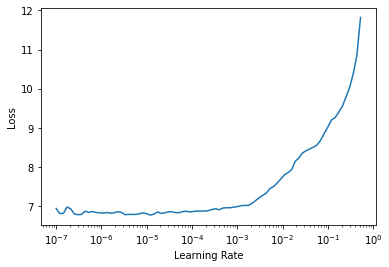

```python
learn.lr_find()
```

Entrenamos durante 10 épocas con el factor de aprendizaje máximo adecuado según la visualización del buscador de factores de aprendizaje.

```python
learn.fit(10, slice(1e-6,1e-4))
learn.save('families3-vgg16-exp6-fepochs1-uepochs10')
```

| epoch | train_loss | valid_loss | custom_accuracy | time |
| --- | --- | --- | --- | --- |
| 0 | 6.378235 | 5.878344 | 0.475113 | 10:12 |
| 1 | 6.048637 | 5.707223 | 0.524251 | 10:12 |
| 2 | 5.890347 | 5.573492 | 0.559961 | 10:12 |
| 3 | 5.668589 | 5.471351 | 0.580796 | 10:12 |
| 4 | 5.551775 | 5.413688 | 0.592488 | 10:13 |
| 5 | 5.518333 | 5.370410 | 0.608462 | 10:11 |
| 6 | 5.428409 | 5.322519 | 0.627214 | 10:12 |
| 7 | 5.370571 | 5.272314 | 0.633812 | 10:12 |
| 8 | 5.241960 | 5.253678 | 0.644461 | 10:13 |
| 9 | 5.200482 | 5.207316 | 0.664024 | 10:12 |

```
Path('models/families3-vgg16-exp6-fepochs1-uepochs10.pth')
```

Defimos una función para continuar el aprendizaje con los pesos guardados.

```python
def continue_training(pth_filename):
    learn = Learner(dls, model, loss_func=loss_func, metrics=custom_accuracy,
                   splitter=custom_splitter).to_fp16()
    learn.load(pth_filename)
    learn.unfreeze()
    return learn
```

```python
learn = continue_training('families3-vgg16-exp6-fepochs1-uepochs10')
```

Continuamos entrenando nuestro modelo hasta las 50 épocas en conjuntos de 10, guardando los pesos del entrenamiento en cada paso.

```python
learn.fit(10, slice(1e-6,1e-4))
learn.save('families3-vgg16-exp6-fepochs1-uepochs20')
```

| epoch | train_loss | valid_loss | custom_accuracy | time |
| --- | --- | --- | --- | --- |
| 0 | 5.117687 | 5.208079 | 0.665876 | 10:06 |
| 1 | 5.195343 | 5.188424 | 0.665702 | 09:59 |
| 2 | 5.067316 | 5.173665 | 0.678724 | 10:00 |
| 3 | 4.957954 | 5.182219 | 0.686306 | 10:01 |
| 4 | 4.987345 | 5.158104 | 0.682023 | 10:01 |
| 5 | 4.920091 | 5.143577 | 0.688737 | 09:59 |
| 6 | 4.890742 | 5.170769 | 0.701412 | 09:57 |
| 7 | 4.894142 | 5.143631 | 0.704306 | 09:56 |
| 8 | 4.817330 | 5.153750 | 0.701065 | 09:58 |
| 9 | 4.739181 | 5.126975 | 0.712062 | 09:56 |

```
Path('models/families3-vgg16-exp6-fepochs1-uepochs20.pth')
```

```python
learn = continue_training('families3-vgg16-exp6-fepochs1-uepochs20')
```

```python
learn.fit(10, slice(1e-6,1e-4))
learn.save('families3-vgg16-exp6-fepochs1-uepochs30')
```

| epoch | train_loss | valid_loss | custom_accuracy | time |
| --- | --- | --- | --- | --- |
| 0 | 4.795174 | 5.136572 | 0.709457 | 10:14 |
| 1 | 4.783936 | 5.188999 | 0.720859 | 10:09 |
| 2 | 4.754017 | 5.127817 | 0.716460 | 10:09 |
| 3 | 4.725422 | 5.134100 | 0.732145 | 10:08 |
| 4 | 4.709015 | 5.155596 | 0.725258 | 10:10 |
| 5 | 4.688787 | 5.171250 | 0.734286 | 10:09 |
| 6 | 4.646172 | 5.156271 | 0.731566 | 10:10 |
| 7 | 4.627205 | 5.193600 | 0.735849 | 10:11 |
| 8 | 4.618552 | 5.175879 | 0.736544 | 10:11 |
| 9 | 4.660257 | 5.178566 | 0.736717 | 10:09 |

```
Path('models/families3-vgg16-exp6-fepochs1-uepochs30.pth')
```

```python
learn = continue_training('families3-vgg16-exp6-fepochs1-uepochs30')
```

```python
learn.fit(10, slice(1e-6,1e-4))
learn.save('families3-vgg16-exp6-fepochs1-uepochs40')
```

| epoch | train_loss | valid_loss | custom_accuracy | time |
| --- | --- | --- | --- | --- |
| 0 | 4.584332 | 5.174459 | 0.740711 | 10:14 |
| 1 | 4.583376 | 5.201556 | 0.750781 | 10:10 |
| 2 | 4.557548 | 5.201235 | 0.745283 | 10:10 |
| 3 | 4.634335 | 5.210611 | 0.751129 | 10:11 |
| 4 | 4.556431 | 5.183159 | 0.751823 | 10:11 |
| 5 | 4.604358 | 5.243662 | 0.752344 | 10:10 |
| 6 | 4.568168 | 5.200585 | 0.756338 | 10:09 |
| 7 | 4.570300 | 5.192603 | 0.759521 | 10:10 |
| 8 | 4.520527 | 5.224530 | 0.763688 | 10:10 |
| 9 | 4.532508 | 5.230136 | 0.758305 | 10:10 |

```
Path('models/families3-vgg16-exp6-fepochs1-uepochs40.pth')
```

```python
learn = continue_training('families3-vgg16-exp6-fepochs1-uepochs40')
```

```python
learn.fit(10, slice(1e-6,1e-4))
learn.save('families3-vgg16-exp6-fepochs1-uepochs50')
```

| epoch | train_loss | valid_loss | custom_accuracy | time |
| --- | --- | --- | --- | --- |
| 0 | 4.566365 | 5.216251 | 0.756338 | 10:43 |
| 1 | 4.514861 | 5.238991 | 0.761604 | 10:37 |
| 2 | 4.475070 | 5.246284 | 0.771559 | 10:38 |
| 3 | 4.557413 | 5.237414 | 0.769823 | 10:37 |
| 4 | 4.470292 | 5.237094 | 0.771675 | 10:38 |
| 5 | 4.496798 | 5.247771 | 0.768434 | 10:39 |
| 6 | 4.499522 | 5.234198 | 0.766003 | 10:40 |
| 7 | 4.516970 | 5.250506 | 0.771154 | 10:39 |
| 8 | 4.482280 | 5.230191 | 0.770402 | 10:39 |
| 9 | 4.488416 | 5.241188 | 0.773353 | 10:39 |

[output not shown]

```python
learn.save('families3-vgg16-exp6-fepochs1-uepochs50')
```

```
Path('models/families3-vgg16-exp6-fepochs1-uepochs50.pth')
```

```python
learn.export('families3-vgg16-exp6-fepochs1-uepochs50')
```

## Experimento 7: 1 Rama (género)

Creamos el cuerpo (*encoder*) y cabeza del modelo tomando como base VGG-16 con *Batch Normalization* y con pesos preentrenados.

```python
model = vgg16_bn
body = create_body(model, cut=-2)
body
```

```
Downloading: "https://download.pytorch.org/models/vgg16_bn-6c64b313.pth" to /root/.cache/torch/hub/checkpoints/vgg16_bn-6c64b313.pth
```

```
Sequential(
  (0): Sequential(
    (0): Conv2d(3, 64, kernel_size=(3, 3), stride=(1, 1), padding=(1, 1))
    (1): BatchNorm2d(64, eps=1e-05, momentum=0.1, affine=True, track_running_stats=True)
    (2): ReLU(inplace=True)
    (3): Conv2d(64, 64, kernel_size=(3, 3), stride=(1, 1), padding=(1, 1))
    (4): BatchNorm2d(64, eps=1e-05, momentum=0.1, affine=True, track_running_stats=True)
    (5): ReLU(inplace=True)
    (6): MaxPool2d(kernel_size=2, stride=2, padding=0, dilation=1, ceil_mode=False)
    (7): Conv2d(64, 128, kernel_size=(3, 3), stride=(1, 1), padding=(1, 1))
    (8): BatchNorm2d(128, eps=1e-05, momentum=0.1, affine=True, track_running_stats=True)
    (9): ReLU(inplace=True)
    (10): Conv2d(128, 128, kernel_size=(3, 3), stride=(1, 1), padding=(1, 1))
    (11): BatchNorm2d(128, eps=1e-05, momentum=0.1, affine=True, track_running_stats=True)
    (12): ReLU(inplace=True)
    (13): MaxPool2d(kernel_size=2, stride=2, padding=0, dilation=1, ceil_mode=False)
    (14): Conv2d(128, 256, kernel_size=(3, 3), stride=(1, 1), padding=(1, 1))
    (15): BatchNorm2d(256, eps=1e-05, momentum=0.1, affine=True, track_running_stats=True)
    (16): ReLU(inplace=True)
    (17): Conv2d(256, 256, kernel_size=(3, 3), stride=(1, 1), padding=(1, 1))
    (18): BatchNorm2d(256, eps=1e-05, momentum=0.1, affine=True, track_running_stats=True)
    (19): ReLU(inplace=True)
    (20): Conv2d(256, 256, kernel_size=(3, 3), stride=(1, 1), padding=(1, 1))
    (21): BatchNorm2d(256, eps=1e-05, momentum=0.1, affine=True, track_running_stats=True)
    (22): ReLU(inplace=True)
    (23): MaxPool2d(kernel_size=2, stride=2, padding=0, dilation=1, ceil_mode=False)
    (24): Conv2d(256, 512, kernel_size=(3, 3), stride=(1, 1), padding=(1, 1))
    (25): BatchNorm2d(512, eps=1e-05, momentum=0.1, affine=True, track_running_stats=True)
    (26): ReLU(inplace=True)
    (27): Conv2d(512, 512, kernel_size=(3, 3), stride=(1, 1), padding=(1, 1))
    (28): BatchNorm2d(512, eps=1e-05, momentum=0.1, affine=True, track_running_stats=True)
    (29): ReLU(inplace=True)
    (30): Conv2d(512, 512, kernel_size=(3, 3), stride=(1, 1), padding=(1, 1))
    (31): BatchNorm2d(512, eps=1e-05, momentum=0.1, affine=True, track_running_stats=True)
    (32): ReLU(inplace=True)
    (33): MaxPool2d(kernel_size=2, stride=2, padding=0, dilation=1, ceil_mode=False)
    (34): Conv2d(512, 512, kernel_size=(3, 3), stride=(1, 1), padding=(1, 1))
    (35): BatchNorm2d(512, eps=1e-05, momentum=0.1, affine=True, track_running_stats=True)
    (36): ReLU(inplace=True)
    (37): Conv2d(512, 512, kernel_size=(3, 3), stride=(1, 1), padding=(1, 1))
    (38): BatchNorm2d(512, eps=1e-05, momentum=0.1, affine=True, track_running_stats=True)
    (39): ReLU(inplace=True)
    (40): Conv2d(512, 512, kernel_size=(3, 3), stride=(1, 1), padding=(1, 1))
    (41): BatchNorm2d(512, eps=1e-05, momentum=0.1, affine=True, track_running_stats=True)
    (42): ReLU(inplace=True)
    (43): MaxPool2d(kernel_size=2, stride=2, padding=0, dilation=1, ceil_mode=False)
  )
)
```

```python
head = create_head(512*2,dls.c)
head
```

```
Sequential(
  (0): AdaptiveConcatPool2d(
    (ap): AdaptiveAvgPool2d(output_size=1)
    (mp): AdaptiveMaxPool2d(output_size=1)
  )
  (1): Flatten(full=False)
  (2): BatchNorm1d(1024, eps=1e-05, momentum=0.1, affine=True, track_running_stats=True)
  (3): Dropout(p=0.25, inplace=False)
  (4): Linear(in_features=1024, out_features=512, bias=False)
  (5): ReLU(inplace=True)
  (6): BatchNorm1d(512, eps=1e-05, momentum=0.1, affine=True, track_running_stats=True)
  (7): Dropout(p=0.5, inplace=False)
  (8): Linear(in_features=512, out_features=144, bias=False)
)
```

Separamos el cuerpo de la arquitectura en los distintos bloques para definir cada uno de ellos y aplicar posteriormente una rama entre el bloque 2 y el bloque 3.

```python
_body = body[0]
block1 = _body[:7]
block2 = _body[7:14]
block3 = _body[14:24]
block4 = _body[24:34]
block5 = _body[34:]
```

Definimos una función para obtener las etiquetas de cada ejemplo, en este caso: el género y la especie.

```python
def custom_get_y(o):
    fine_label = o['Specie']
    coarse1_label = o['Genus']
    return [coarse1_label, fine_label]
```

Creamos una clase para nuestro modelo que divida el *encoder* en los distintos bloques y añada una cabeza entre el bloque 2 y 3 como rama con el número de clases de *Género*. En el método *forward* establecemos la conexión de los distintos bloques, separando la salida de la rama del flujo normal, para así devolver ambas salidas en forma de diccionario.

```python
class VGGCustomModel(Module):
    def __init__(self, encoder, head):
        self.encoder = encoder
        encoder = encoder[0]
        self.block1 = encoder[:7]
        self.block2 = encoder[7:14]
        self.branch1 = create_head(128*2, len(set(df['Genus'])))
        self.block3 = encoder[14:24]
        self.block4 = encoder[24:34]
        self.block5 = encoder[34:]
        self.head = head

    def forward(self, x):
        x = self.block1(x)
        x = self.block2(x)
        coarse1_label = self.branch1(x)
        x = self.block3(x)
        x = self.block4(x)
        x = self.block5(x)
        fine_label = self.head(x)
        return {
                'fine_label': fine_label,
                'coarse1_label': coarse1_label
               }
```

Creamos el modelo con la clase definida pasándole el cuerpo y cabeza.

```python
model = VGGCustomModel(body, head)
```

Como hemos modificado el modelo y la obtención de las clases para usar una salida múltiple, tenemos que modificar el tipo de bloque de categoría a uno que soporte estas salidas. Para ello, definimos una función que obtenga la clase y codifique a categoría cada una.

```python
class CustomCategorize(DisplayedTransform):
    "Reversible transform of category string to `vocab` id"
    loss_func,order=CrossEntropyLossFlat(),1
    def __init__(self, vocab=None, vocab_coarse1=None, vocab_coarse2=None, sort=True, add_na=False, num_y=1):
        store_attr()
        self.vocab = None if vocab is None else CategoryMap(vocab, sort=sort, add_na=add_na)
        self.vocab_coarse1 = None if vocab_coarse1 is None else CategoryMap(vocab_coarse1, sort=sort, add_na=add_na)

    def setups(self, dsets):
        fine_dsets = [d[1] for d in dsets]
        coarse1_dsets = [d[0] for d in dsets]
        if self.vocab is None and dsets is not None: self.vocab = CategoryMap(fine_dsets, sort=self.sort, add_na=self.add_na)
        if self.vocab_coarse1 is None and dsets is not None: self.vocab_coarse1 = CategoryMap(coarse1_dsets, sort=self.sort, add_na=self.add_na)
        self.c = len(self.vocab)

    def encodes(self, o): return {'fine_label': TensorCategory(self.vocab.o2i[o[1]]),
                                  'coarse1_label': TensorCategory(self.vocab_coarse1.o2i[o[0]])
                                 }
    def decodes(self, o): return Category      (self.vocab    [o])
```

```python
def CustomCategoryBlock(vocab=None, sort=True, add_na=False, num_y=1):
    "`TransformBlock` for single-label categorical targets"
    return TransformBlock(type_tfms=CustomCategorize(vocab=vocab, sort=sort, add_na=add_na))
```

Creamos un *splitter* personalizado con los parámetros de cada bloque y del *head*.

```python
def custom_splitter(model):
    return [params(model.block1),
            params(model.block2),
            params(model.block3),
            params(model.block4),
            params(model.block5),
            params(model.head)]
```

Creamos un *datablock* con: bloques de tipo imagen y categoría personalizada *CustomCategoryBlock*, un separador por columna, la *x* con la columna que contienen la ruta de las imágenes, la *y* con la función personalizada, una transformación para hacer un recorte aleatorio dejando un tamaño común de 336x336, y las transformaciones de aumento de datos por defecto.

```python
fishes = DataBlock(blocks = (ImageBlock, CustomCategoryBlock),
                 splitter=ColSplitter(),
                 get_x = ColReader(5, pref=path),
                 get_y=custom_get_y,
                 item_tfms=RandomResizedCrop(336, min_scale=0.5),
                 batch_tfms=aug_transforms())
dls = fishes.dataloaders(df)
```

Mostramos los *dataloaders* generados con el *datablock*.

```python
dls.train_ds, dls.valid_ds
```

```
((#69110) [(PILImage mode=RGB size=1024x768, {'fine_label': TensorCategory(13), 'coarse1_label': TensorCategory(5)}),(PILImage mode=RGB size=1024x768, {'fine_label': TensorCategory(83), 'coarse1_label': TensorCategory(29)}),(PILImage mode=RGB size=768x1024, {'fine_label': TensorCategory(83), 'coarse…
 (#17278) [(PILImage mode=RGB size=768x1024, {'fine_label': TensorCategory(83), 'coarse1_label': TensorCategory(29)}),(PILImage mode=RGB size=1024x636, {'fine_label': TensorCategory(83), 'coarse1_label': TensorCategory(29)}),(PILImage mode=RGB size=1024x768, {'fine_label': TensorCategory(52), 'coars…
```

Mostramos las clases finas y las categóricas de nuestros dataloaders.

```python
dls.vocab, dls.vocab_coarse1
```

```
(['Abramis brama', 'Abudefduf abdominalis', 'Abudefduf bengalensis', 'Abudefduf saxatilis', 'Abudefduf septemfasciatus', 'Abudefduf sexfasciatus', 'Abudefduf sordidus', 'Abudefduf troschelii', 'Abudefduf vaigiensis', 'Acanthochromis polyacanthus', 'Acrossocheilus paradoxus', 'Alburnus alburnus', 'Al…
 ['Abramis', 'Abudefduf', 'Acanthochromis', 'Acrossocheilus', 'Alburnus', 'Ambloplites', 'Amblyglyphidodon', 'Amphiprion', 'Barbus', 'Campostoma', 'Candidia', 'Carassius', 'Centrarchus', 'Chromis', 'Chrosomus', 'Chrysiptera', 'Clinostomus', 'Ctenopharyngodon', 'Cyprinella', 'Cyprinus', 'Dascyllus', …
```

Creamos el tensor con los pesos por clase y lo pasamos a GPU para poder usarlo durante el entrenamiento.

```python
weights = tensor([float(weights_df[weights_df['Specie']==c]['Weight']) for c in dls.vocab]).cuda()
weights_genus = tensor([float(weights_genus_df[weights_genus_df['Genus']==c]['Weight']) for c in dls.vocab_coarse1]).cuda()
```

Defimos nuestra función de pérdida como el sumatorio de la pérdida en entropía cruzada de las dos salidas.

```python
def loss_func(out, targ):
    return nn.CrossEntropyLoss(weight=weights)(out['fine_label'], targ['fine_label']) + \
            nn.CrossEntropyLoss(weight=weights_genus)(out['coarse1_label'], targ['coarse1_label'])
```

Defimos la función de accuracy con la etiqueta fina, ya que es el resultado final que nos interesa. Además, esta etiqueta fue la que se usó para definir las particiones estratificadas, por lo que es la única que se debería tener en cuenta si queremos resultados más fiables.

```python
def custom_accuracy(inp, targ, axis=-1):
    pred1,targ1 = flatten_check(inp['fine_label'].argmax(dim=axis), targ['fine_label'])
    acc1 = (pred1 == targ1).float().mean()
    return acc1
```

Creamos nuestro objeto *Learner* con los *dataloaders*, la función de pérdida _loss*func* creada, la métrica exactitud y el *splitter* creado. Además, congelamos nuestro modelo para ajustar primero los pesos preentrenados a nuestras clases.

```python
learn = Learner(dls, model, loss_func=loss_func, metrics=custom_accuracy,
                   splitter=custom_splitter).to_fp16()
learn.freeze()
```

Mostramos un resumen de nuestro modelo.

```python
learn.summary()
```

| epoch | train_loss | valid_loss | custom_accuracy | time |
| --- | --- | --- | --- | --- |
| 0 | None | None | 00:00 |  |

```
VGGCustomModel (Input shape: ['64 x 3 x 336 x 336'])
================================================================
Layer (type)         Output Shape         Param #    Trainable
================================================================
Conv2d               64 x 64 x 336 x 336  1,792      False
________________________________________________________________
BatchNorm2d          64 x 64 x 336 x 336  128        True
________________________________________________________________
ReLU                 64 x 64 x 336 x 336  0          False
________________________________________________________________
Conv2d               64 x 64 x 336 x 336  36,928     False
________________________________________________________________
BatchNorm2d          64 x 64 x 336 x 336  128        True
________________________________________________________________
ReLU                 64 x 64 x 336 x 336  0          False
________________________________________________________________
MaxPool2d            64 x 64 x 168 x 168  0          False
________________________________________________________________
Conv2d               64 x 128 x 168 x 16  73,856     False
________________________________________________________________
BatchNorm2d          64 x 128 x 168 x 16  256        True
________________________________________________________________
ReLU                 64 x 128 x 168 x 16  0          False
________________________________________________________________
Conv2d               64 x 128 x 168 x 16  147,584    False
________________________________________________________________
BatchNorm2d          64 x 128 x 168 x 16  256        True
________________________________________________________________
ReLU                 64 x 128 x 168 x 16  0          False
________________________________________________________________
MaxPool2d            64 x 128 x 84 x 84   0          False
________________________________________________________________
Conv2d               64 x 256 x 84 x 84   295,168    False
________________________________________________________________
BatchNorm2d          64 x 256 x 84 x 84   512        True
________________________________________________________________
ReLU                 64 x 256 x 84 x 84   0          False
________________________________________________________________
Conv2d               64 x 256 x 84 x 84   590,080    False
________________________________________________________________
```

[output cut: 181 more lines]

```
Total params: 30,208,640
Total trainable params: 779,264
Total non-trainable params: 29,429,376

Optimizer used: <function Adam at 0x7fc6d9535160>
Loss function: <function loss_func at 0x7fc6fe713dc0>

Model frozen up to parameter group #5

Callbacks:
  - ModelToHalf
  - TrainEvalCallback
  - Recorder
  - ProgressCallback
  - MixedPrecision
```

Entrenamos el modelo congelado para ajustar los pesos de las últimas capas a nuestras clases, y descongelamos el modelo.

```python
learn.fit(1, 3e-3)
learn.save('families3-vgg16-exp7-fepochs1-uepochs0')
```

| epoch | train_loss | valid_loss | custom_accuracy | time |
| --- | --- | --- | --- | --- |
| 0 | 7.104291 | 6.483642 | 0.350735 | 08:44 |

```
Path('models/families3-vgg16-exp7-fepochs1-uepochs0.pth')
```

```python
learn.unfreeze()
```

Buscamos el factor de aprendizaje más adecuado con lr_find.

```
SuggestedLRs(lr_min=3.311311274956097e-07, lr_steep=9.12010818865383e-07)
```

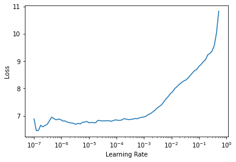

```python
learn.lr_find()
```

Entrenamos durante 10 épocas con el factor de aprendizaje máximo adecuado según la visualización del buscador de factores de aprendizaje.

```python
learn.fit(10, slice(1e-6,1e-4))
learn.save('families3-vgg16-exp7-fepochs1-uepochs10')
```

| epoch | train_loss | valid_loss | custom_accuracy | time |
| --- | --- | --- | --- | --- |
| 0 | 6.385205 | 5.843668 | 0.460296 | 10:36 |
| 1 | 6.030461 | 5.625901 | 0.519447 | 10:38 |
| 2 | 5.843280 | 5.496644 | 0.535421 | 10:38 |
| 3 | 5.668468 | 5.407938 | 0.576803 | 10:39 |
| 4 | 5.529306 | 5.311919 | 0.584500 | 10:38 |
| 5 | 5.423767 | 5.251792 | 0.611876 | 10:38 |
| 6 | 5.270119 | 5.200778 | 0.617838 | 10:40 |
| 7 | 5.179986 | 5.159571 | 0.632481 | 10:39 |
| 8 | 5.191875 | 5.120587 | 0.637632 | 10:38 |
| 9 | 5.066171 | 5.070978 | 0.664776 | 10:38 |

```
Path('models/families3-vgg16-exp7-fepochs1-uepochs10.pth')
```

Defimos una función para continuar el aprendizaje con los pesos guardados.

```python
def continue_training(pth_filename):
    learn = Learner(dls, model, loss_func=loss_func, metrics=custom_accuracy,
                   splitter=custom_splitter).to_fp16()
    learn.load(pth_filename)
    learn.unfreeze()
    return learn
```

```python
learn = continue_training('families3-vgg16-exp7-fepochs1-uepochs10')
```

Continuamos entrenando nuestro modelo hasta las 50 épocas, guardando los pesos del entrenamiento en cada 10 épocas.

```python
learn.fit(10, slice(1e-6,1e-4))
learn.save('families3-vgg16-exp7-fepochs1-uepochs20')
```

| epoch | train_loss | valid_loss | custom_accuracy | time |
| --- | --- | --- | --- | --- |
| 0 | 5.034783 | 5.067281 | 0.659914 | 10:01 |
| 1 | 4.980362 | 5.055021 | 0.669059 | 09:57 |
| 2 | 4.871576 | 5.015667 | 0.669927 | 09:57 |
| 3 | 4.865853 | 5.008879 | 0.678377 | 09:58 |
| 4 | 4.795084 | 4.981162 | 0.693425 | 09:59 |
| 5 | 4.763379 | 4.978048 | 0.685728 | 09:58 |
| 6 | 4.738406 | 4.968178 | 0.688332 | 09:58 |
| 7 | 4.751132 | 4.953498 | 0.704653 | 09:58 |
| 8 | 4.676208 | 4.952890 | 0.700428 | 09:58 |
| 9 | 4.648600 | 4.966298 | 0.710036 | 09:57 |

```
Path('models/families3-vgg16-exp7-fepochs1-uepochs20.pth')
```

```python
learn = continue_training('families3-vgg16-exp7-fepochs1-uepochs20')
```

```python
learn.fit(10, slice(1e-6,1e-4))
learn.save('families3-vgg16-exp7-fepochs1-uepochs30')
```

| epoch | train_loss | valid_loss | custom_accuracy | time |
| --- | --- | --- | --- | --- |
| 0 | 4.567300 | 4.958863 | 0.711020 | 10:08 |
| 1 | 4.568475 | 4.955159 | 0.720106 | 10:03 |
| 2 | 4.527318 | 4.946325 | 0.724563 | 10:03 |
| 3 | 4.604189 | 4.956650 | 0.714377 | 10:04 |
| 4 | 4.547755 | 4.937747 | 0.718428 | 10:03 |
| 5 | 4.511087 | 4.933128 | 0.728846 | 10:04 |
| 6 | 4.442406 | 4.920926 | 0.723984 | 10:04 |
| 7 | 4.451516 | 4.944375 | 0.730409 | 10:04 |
| 8 | 4.432858 | 4.954243 | 0.734055 | 10:05 |
| 9 | 4.426845 | 4.919935 | 0.739090 | 10:04 |

```
Path('models/families3-vgg16-exp7-fepochs1-uepochs30.pth')
```

```python
learn = continue_training('families3-vgg16-exp7-fepochs1-uepochs30')
```

```python
learn.fit(10, slice(1e-6,1e-4))
learn.save('families3-vgg16-exp7-fepochs1-uepochs40')
```

| epoch | train_loss | valid_loss | custom_accuracy | time |
| --- | --- | --- | --- | --- |
| 0 | 4.424553 | 4.941157 | 0.737585 | 10:12 |
| 1 | 4.372528 | 4.920524 | 0.738280 | 10:05 |
| 2 | 4.368244 | 4.938570 | 0.744010 | 10:07 |
| 3 | 4.360896 | 4.928634 | 0.747714 | 10:07 |
| 4 | 4.347248 | 4.928809 | 0.744994 | 10:07 |
| 5 | 4.318280 | 4.950066 | 0.746151 | 10:06 |
| 6 | 4.333688 | 4.965881 | 0.743373 | 10:09 |
| 7 | 4.325279 | 4.972905 | 0.753502 | 10:08 |
| 8 | 4.320052 | 4.972100 | 0.753270 | 10:08 |
| 9 | 4.314194 | 4.995737 | 0.758884 | 10:07 |

```
Path('models/families3-vgg16-exp7-fepochs1-uepochs40.pth')
```

```python
learn = continue_training('families3-vgg16-exp7-fepochs1-uepochs40')
```

```python
learn.fit(10, slice(1e-6,1e-4))
learn.save('families3-vgg16-exp7-fepochs1-uepochs50')
```

| epoch | train_loss | valid_loss | custom_accuracy | time |
| --- | --- | --- | --- | --- |
| 0 | 4.297798 | 4.960443 | 0.756222 | 10:07 |
| 1 | 4.272234 | 4.939277 | 0.756453 | 10:03 |
| 2 | 4.232387 | 4.914865 | 0.764498 | 10:03 |
| 3 | 4.253362 | 4.943645 | 0.770112 | 10:03 |
| 4 | 4.251673 | 4.941692 | 0.762588 | 10:03 |
| 5 | 4.207457 | 4.936532 | 0.759174 | 10:03 |
| 6 | 4.254735 | 4.919722 | 0.764961 | 10:05 |
| 7 | 4.139572 | 4.912082 | 0.768144 | 10:05 |
| 8 | 4.214478 | 4.948819 | 0.775379 | 10:05 |
| 9 | 4.226850 | 4.967545 | 0.774569 | 10:05 |

```
Path('models/families3-vgg16-exp7-fepochs1-uepochs50.pth')
```

```python
learn.export('families3-vgg16-exp7-fepochs1-uepochs50')
```